# Machine Learning Coursework 1(30061694)

## EXPLORING MACHINE LEARNING ANALYSIS ON THE SCHIZOPHRENIA-LIKE ILLNESS WITH DIAGNOSIS

## INTRODUCTION

Modern machine learning models are being used for disease detection and diagnosis, which is causing a revolution in the medical sciences. The use of algorithms to diagnose and offer information on problems like dementia, diabetes, and many types of cancer has shown a lot of promise in recent years, giving hope to the millions of people who experience these conditions. Many additional critical illnesses, including neuropsychiatric disorders like schizophrenia, may not yet have their secrets unlocked by the machine learning revolution because to the intricacy of these conditions and the paucity of available data. A dangerous and incapacitating mental illness, schizophrenia. There are varying degrees of social function faults, a slow and progressive development of the condition, and manifestations such as impediments to thinking, emotion, and action. False beliefs, clouded or muddled thinking, hearing voices that only you can hear, decreased social engagement and emotional expression, and lack of desire are all symptoms. It not only causes the sufferer enormous suffering, but it also places a significant cost on society and the family. Around 1% of the world's population has the disease. The majority of the datasets for these types of disorders that are now accessible are actually far too tiny to allow for the meaningful extraction of information, and many of these datasets show clear biases about the race, socioeconomic position, and severity of the participants' ailments. Real-world schizophrenia is a severe neuropsychiatric condition characterized by cognitive symptoms, disorganized thinking, social disengagement, diminished emotional expression, and positive symptoms (hallucinations, delusions). The information we'll look at is made up and mostly made up (poorer working memory and general cognitive ability). Schizophrenia affects 0.5% of people at some point in their lives, and it often first manifests around adolescence and the early years of adulthood. Schizophrenia can be made better through early detection, intervention, and therapy. The goal of the cure rate is to stop the disease from progressing slowly. The aetiology and pathogenesis of schizophrenia are still unknown, and there aren't any objective laboratory diagnostic markers or equipment diagnostic criteria. Clinical diagnoses are mostly made using a patient's medical history, together with psychiatric symptoms, the disease's law of progression, and scales. The difficulty in making an early diagnosis of schizophrenia is still a result of the intricacy of the disease mechanism. Schizophrenia primarily affects persons between the ages of 15 and 34 and has a severe detrimental impact on human perception, thought, emotion, and conduct. Early controlled, late repeated attacks, and significantly compromised cognitive function are the features of this illness. Both hereditary and environmental factors raise the risk of developing schizophrenia. Recent research have connected a number of genes to the condition, but it is still unclear how the disorder is impacted by the mix of genetic and environmental factors. The aetiology of schizophrenia is the subject of numerous conflicting ideas, but the fundamental molecular causes of the illness are largely unknown. The diagnosis of schizophrenia must be made primarily on an individual's behaviour, their medical history, and long-term observations of functional impairment because there are no objective diagnostic tests for the condition. The way this process is carried out varies a lot between countries and even between different medical specialties. Schizophrenia is especially challenging to identify because of negative signs of the illness such social isolation, symptoms that match with those of other mental illnesses, and cases when sufferers do not immediately exhibit favourable signals. Some of the most frequent psychiatric diagnoses that people obtain initially include bipolar disease, borderline personality disorder, and schizoaffective disorder, which can result in poor treatment management. With enough high-quality data and a better biological understanding of such conditions, it is hoped that machine learning will one day be able to identify people who exhibit symptoms of schizophrenia more accurately than clinicians, which may aid in the treatment and prognosis of this crippling condition. It is essential that healthcare professionals and machine learning scientists/engineers collaborate in order to fully realise the incredible potential of machine learning in healthcare, while keeping in mind the potentially harmful limitations and side effects that using historical medical data brings limits and drawbacks associated with using previous medical data.

## UNDERSTANDING THE DATASET

This dataset contains information on the symptoms and manner of life of 5,000 hypothetical people. The data is contained in a single.csv file with the name "MS4S16 Dataset.csv." The file is comma-delimited and has 5,000 rows and 27 columns (a mixture of numerical and categorical features). If the observation has a value of 1, it refers to a "case," or a person who has the schizophrenia-like illness. If the observation has a value of 0, it refers to a "control," or a person who does not have the schizophrenia-like illness.

## ANALYSIS AND INTERPRETATIONS

## Importing Libraries

```python
#loading relevant libraries
import os
import pandas as pd
import numpy as np
import seaborn as sns
import matplotlib.pyplot as plt

from sklearn.model_selection import train_test_split
from sklearn.linear_model import LogisticRegression
from sklearn.metrics import classification_report, confusion_matrix
from sklearn.preprocessing import OneHotEncoder
from sklearn import linear_model
from sklearn import metrics
```

## Importing Data

```python
#importing the dataset
MS4S16_Dataset = pd.read_csv("C:/Users/HP/Desktop/coursework dataset/MS4S16_Dataset.csv")
```

```python
#displaying the dataset
MS4S16_Dataset
```

|  | Diagnosis | Anhedonia | Apathy | Appetite | Concentration | Content | Delay | Delusion | Dep_Mood | Focus | ... | Race | Rumination | Sex | Sleep | Stress | Suspicious | Tension | Tired | Unusual_Thought | Withdrawal |
| --- | --- | --- | --- | --- | --- | --- | --- | --- | --- | --- | --- | --- | --- | --- | --- | --- | --- | --- | --- | --- | --- |
| 0 | 1 | 4.501446 | 3.056575 | 9.283891 | 8.305502 | 0.006142 | Yes | 1.170842 | 8.177884 | 8.305502 | ... | White | 5.041432 | Female | 6.552082 | 5.915492 | 3.991749 | 6.371877 | 4.537270 | 3.744410 | 5.242819 |
| 1 | 0 | 5.432608 | 0.307721 | 25.809400 | 5.060206 | 0.062209 | Yes | 2.272548 | 11.162913 | 5.060206 | ... | White | 4.656790 | Male | 5.558434 | 4.008265 | NaN | 2.238665 | 6.113746 | 0.720458 | 3.797242 |
| 2 | 0 | 6.557500 | -1.412208 | 24.842012 | 6.504229 | 0.071532 | No | 1.439095 | 5.887363 | 6.504229 | ... | Black | 7.290494 | Female | 5.787561 | 7.177926 | NaN | 6.992499 | 5.557374 | -0.491255 | 4.421288 |
| 3 | 0 | 5.429568 | 1.686157 | 24.175853 | 6.994948 | 0.278345 | No | 1.380185 | 8.943851 | 6.994948 | ... | White | 6.759339 | Female | 6.787287 | 2.866815 | NaN | 4.018286 | 6.136269 | 0.765388 | 2.299562 |
| 4 | 1 | 5.099846 | -0.612506 | 45.808490 | 5.869212 | 0.004214 | Yes | 1.237976 | 6.741627 | 5.869212 | ... | Black | 6.190019 | Male | 7.748312 | 6.798220 | 5.103103 | 5.063542 | 4.213723 | 0.705895 | 6.547707 |
| 5 | 1 | 4.741820 | 5.249279 | 40.546297 | 6.304295 | 0.036026 | Yes | 3.367918 | 9.083414 | 6.304295 | ... | Asian | 3.350354 | Female | 7.079464 | 7.973631 | 4.169943 | 6.395395 | 7.019037 | 5.068805 | 1.807273 |
| 6 | 1 | 6.608759 | 3.136189 | 32.400421 | 5.519083 | 0.443484 | Yes | 4.001160 | 8.448621 | 5.519083 | ... | Black | 4.317049 | Female | 7.312760 | 5.851583 | 1.580934 | 5.886116 | 4.956073 | 2.725966 | 3.570889 |
| 7 | 1 | 7.150700 | 3.416662 | 34.460302 | 8.355920 | 0.340528 | No | 2.862363 | 0.000000 | 8.355920 | ... | Asian | 5.219549 | Female | 6.515927 | 5.762496 | NaN | 7.290513 | 3.882223 | 3.762395 | 3.534289 |
| 8 | 0 | 4.176741 | 2.296168 | 52.235631 | 5.509529 | 0.196207 | Yes | 0.274118 | 0.000000 | 5.509529 | ... | Hispanic | 7.764909 | Female | 7.934684 | 6.125694 | NaN | 5.561847 | 5.891835 | 2.804849 | 4.565072 |
| 9 | 0 | 5.185233 | 2.891209 | 26.396848 | 3.490360 | 0.003706 | Yes | 2.839490 | 8.656884 | 3.490360 | ... | Hispanic | 8.536703 | Female | 6.081508 | 7.560122 | NaN | 5.833136 | 6.213946 | 0.705924 | 4.175766 |
| 10 | 1 | 8.060203 | 4.995976 | 23.559857 | 7.569503 | 0.037921 | Yes | 1.439270 | 3.482523 | 7.569503 | ... | Hispanic | 2.519294 | Male | 7.478541 | 5.015264 | 3.495803 | 6.470819 | 5.484966 | 4.948959 | 2.011998 |
| 11 | 1 | 6.752766 | 1.970964 | 42.217354 | 7.695459 | 0.032136 | No | 2.950428 | 0.000000 | 7.695459 | ... | White | 6.119241 | Male | 5.816101 | 7.320582 | NaN | 7.261234 | 4.138408 | 2.989974 | 3.797660 |
| 12 | 0 | 8.745443 | 2.110826 | 41.402504 | 4.600058 | 0.150450 | No | 1.523567 | 11.323310 | 4.600058 | ... | Asian | 5.345654 | Male | 8.346023 | 2.440750 | NaN | 2.561870 | 6.582941 | 1.315633 | 1.933426 |
| 13 | 0 | 9.095487 | 2.092819 | 20.793348 | 4.334576 | 0.147777 | No | 3.428896 | 9.392531 | 4.334576 | ... | Hispanic | 6.733054 | Female | 7.084464 | 4.676158 | 1.461483 | 4.880672 | 5.835438 | 2.328283 | 3.961009 |
| 14 | 0 | 7.122978 | -0.274233 | 23.984754 | 3.960052 | 0.018161 | Yes | 2.492150 | 6.540927 | 3.960052 | ... | Hispanic | 7.960308 | Female | 6.667823 | 6.093812 | NaN | 6.666544 | 5.406406 | -0.648984 | 4.482266 |
| 15 | 1 | 7.246154 | 3.574174 | 3.675811 | 7.512099 | 0.002079 | Yes | 2.218384 | 7.177058 | 7.512099 | ... | Black | 6.542324 | Female | 5.978012 | 6.630028 | NaN | 6.947103 | 3.025066 | 3.226544 | 4.176311 |
| 16 | 0 | 6.553485 | 2.792001 | 18.537699 | 7.528801 | 0.939528 | Yes | 2.406530 | 8.089492 | 7.528801 | ... | White | 5.762785 | Male | 5.592979 | 1.633497 | NaN | 2.776555 | 6.984767 | 2.830381 | 4.962306 |
| 17 | 1 | 5.953953 | 4.479288 | 17.535036 | 7.630108 | 0.093171 | Yes | 5.933476 | 8.374044 | 7.630108 | ... | White | 7.731844 | Male | 5.044487 | 4.189515 | 3.240071 | 4.930459 | 6.478183 | 3.329147 | 6.681249 |
| 18 | 1 | 5.452113 | 0.739006 | 5.224380 | 9.105690 | 0.016825 | Yes | 3.004196 | 8.043615 | 9.105690 | ... | White | 5.806578 | Female | 5.634240 | 5.926892 | 3.793296 | 5.791106 | 6.023240 | 1.509301 | 4.734220 |
| 19 | 0 | 4.228123 | 0.905521 | 15.879692 | 5.572261 | 0.597682 | No | 0.504865 | 6.215001 | 5.572261 | ... | Black | 7.930826 | Female | 6.700398 | 8.363227 | -0.446866 | 7.050481 | 6.739636 | 0.909979 | 2.317255 |
| 20 | 0 | 8.433511 | 3.246017 | 17.852691 | 8.008901 | 0.010824 | Yes | 1.343160 | 8.716224 | 8.008901 | ... | Asian | 4.261341 | Male | 6.848552 | 4.962825 | NaN | 5.089003 | 4.278555 | 1.750928 | 2.251646 |
| 21 | 0 | 7.877249 | 2.037046 | 16.962552 | 5.276860 | 0.116928 | No | 4.406413 | 6.652407 | 5.276860 | ... | Asian | 6.991543 | Male | 9.286485 | 2.437377 | NaN | 2.154542 | 4.684327 | 2.168894 | 2.970326 |
| 22 | 0 | 9.964745 | 1.417324 | 3.212219 | 7.752039 | 0.273541 | Yes | 3.682216 | 5.462605 | 7.752039 | ... | Black | 7.127016 | Female | 6.917810 | 5.516323 | 1.846890 | 6.270617 | 4.529713 | 0.129839 | 4.591809 |
| 23 | 1 | 6.849099 | 3.505499 | 55.822219 | 7.086283 | 0.014957 | Yes | 1.771963 | 8.513921 | 7.086283 | ... | White | 5.523200 | Female | 6.711177 | 4.298531 | NaN | 5.490541 | 5.574121 | 4.683611 | 1.654164 |
| 24 | 0 | 5.367756 | 1.849141 | 22.420123 | 5.610663 | 0.013150 | No | 2.394097 | 5.480421 | 5.610663 | ... | White | 6.410653 | Male | 6.021227 | 2.380186 | NaN | 3.257411 | 5.244610 | 2.431912 | 2.532907 |
| 25 | 1 | 5.398893 | 5.668140 | 35.298660 | 8.831141 | 0.014926 | Yes | 2.668686 | 6.836210 | 8.831141 | ... | Black | 3.090999 | Female | 8.673781 | 4.801524 | 3.809082 | 5.349681 | 3.520569 | 4.009502 | 4.014427 |
| 26 | 0 | 6.094305 | 2.784335 | 33.858224 | 5.220698 | 0.012199 | Yes | 2.782884 | 0.000000 | 5.220698 | ... | Hispanic | 5.334738 | Male | 7.399275 | 5.061433 | NaN | 3.126732 | 7.110156 | 2.325198 | 2.405589 |
| 27 | 0 | 7.082530 | 2.261606 | 48.739883 | 6.777505 | 0.026424 | No | 1.778631 | 9.424249 | 6.777505 | ... | White | 7.166094 | Female | 6.128279 | 1.939595 | NaN | 2.532041 | 6.554835 | 0.950429 | 4.810888 |
| 28 | 1 | 4.224259 | 2.564913 | 39.480308 | 8.213267 | 0.299862 | Yes | 4.522135 | 8.075621 | 8.213267 | ... | White | 6.014294 | Female | 8.832740 | 6.254939 | 1.232689 | 6.668385 | 2.202335 | 2.116100 | 1.013992 |
| 29 | 0 | 7.700608 | 0.636408 | 36.761309 | 5.370435 | 0.083866 | No | -0.627327 | 7.093312 | 5.370435 | ... | Black | 2.918361 | Male | 8.122480 | 5.027687 | 1.058356 | 3.934439 | 4.557574 | 1.252309 | 3.814878 |
| ... | ... | ... | ... | ... | ... | ... | ... | ... | ... | ... | ... | ... | ... | ... | ... | ... | ... | ... | ... | ... | ... |
| 4970 | 1 | 6.322317 | 1.932337 | 30.310831 | 6.926281 | 0.001125 | Yes | 1.074066 | 6.732615 | 6.926281 | ... | Asian | 4.663075 | Female | 6.047937 | 6.739240 | NaN | 6.245167 | 3.991712 | 2.816982 | 2.007052 |
| 4971 | 1 | 4.932279 | 3.115098 | 26.627377 | 8.766304 | 0.026915 | Yes | 3.001095 | 0.000000 | 8.766304 | ... | Asian | 3.673550 | Male | 5.690091 | 7.565921 | NaN | 6.105429 | 5.046809 | 1.769517 | 4.320229 |
| 4972 | 0 | 7.969933 | 5.356544 | 9.005683 | 6.230924 | 0.010370 | No | 3.753997 | 0.000000 | 6.230924 | ... | White | 8.031170 | Female | 6.078481 | -0.132351 | NaN | 0.801407 | 5.534910 | 3.976336 | 2.291374 |
| 4973 | 0 | 8.052007 | 0.245599 | 32.673282 | 5.677884 | 0.023099 | No | 2.543267 | 7.363887 | 5.677884 | ... | Black | 6.622406 | Female | 6.438078 | 6.103802 | NaN | 4.845223 | 4.212833 | 2.147638 | 5.209791 |
| 4974 | 1 | 7.532437 | 3.809152 | 7.476118 | 3.906331 | 0.038924 | Yes | 2.296658 | 6.834889 | 3.906331 | ... | Black | 3.335750 | Female | 8.450901 | 5.203907 | 2.533438 | 6.693269 | 5.712951 | 3.779352 | 2.412875 |
| 4975 | 1 | 5.821762 | 2.751301 | 15.125588 | 6.935933 | 0.055483 | Yes | 2.338316 | 5.859163 | 6.935933 | ... | Black | 3.478740 | Male | 7.903001 | 5.517958 | NaN | 4.087273 | 3.018369 | 1.907175 | 3.102634 |
| 4976 | 0 | 6.618214 | 3.114161 | 72.509868 | 7.688757 | 0.204873 | Yes | 1.860521 | 8.799597 | 7.688757 | ... | Hispanic | 4.457720 | Male | 7.382632 | 4.718079 | NaN | 3.216697 | 6.092270 | 2.034873 | 4.214581 |
| 4977 | 0 | 8.947034 | 2.657104 | 27.867260 | 7.189758 | 0.073078 | No | 1.457279 | 6.959514 | 7.189758 | ... | Black | 9.529426 | Female | 7.895658 | 9.079300 | 2.318314 | 8.171962 | 5.395528 | 2.036552 | 4.528671 |
| 4978 | 0 | 6.487598 | 3.293639 | 9.920659 | 3.980330 | 0.183186 | No | 1.610488 | 7.627560 | 3.980330 | ... | Asian | 5.788823 | Female | 4.765354 | 5.712969 | NaN | 6.165153 | 6.093464 | 2.834148 | 5.158258 |
| 4979 | 0 | 7.175628 | 1.147763 | 27.945838 | 9.495171 | 0.080938 | Yes | 4.211235 | 0.000000 | 9.495171 | ... | Black | 8.281979 | Female | 8.258932 | 7.358910 | NaN | 6.486572 | 7.065302 | 1.371895 | 2.508342 |
| 4980 | 0 | 6.553685 | 1.846938 | 55.561731 | 7.462806 | 0.070935 | Yes | 1.593259 | 4.751636 | 7.462806 | ... | Black | 6.560031 | Female | 6.074241 | 4.103582 | NaN | 4.782782 | 4.671167 | 1.509910 | 2.976090 |
| 4981 | 1 | 4.895836 | 8.080668 | 8.946832 | 7.681086 | 0.053206 | Yes | 3.960946 | 5.554169 | 7.681086 | ... | White | 4.513509 | Male | 9.820413 | 7.654209 | 3.674908 | 8.214327 | 5.319984 | 7.221299 | 1.445570 |
| 4982 | 0 | 6.415584 | 2.697319 | 34.913531 | 8.548397 | 0.017608 | No | 2.506987 | 0.000000 | 8.548397 | ... | Hispanic | 2.506044 | Male | 5.537664 | 6.236475 | NaN | 5.491385 | 6.235334 | 2.483979 | 1.352114 |
| 4983 | 0 | 7.199459 | 2.224966 | 69.941235 | 6.599882 | 0.585097 | No | 3.682006 | 0.000000 | 6.599882 | ... | Black | 8.704631 | Female | 8.745036 | 5.916144 | NaN | 5.134676 | 6.726293 | 2.008750 | 2.807307 |
| 4984 | 0 | 9.486103 | 4.579750 | 17.984760 | 6.830462 | 0.020477 | No | 1.089651 | 0.000000 | 6.830462 | ... | Black | 7.582317 | Female | 7.437059 | 4.747011 | NaN | 5.060241 | 6.849409 | 1.428420 | 2.517659 |
| 4985 | 0 | 6.026825 | 0.052504 | 40.865273 | 6.830011 | 0.024636 | No | 3.251588 | 0.000000 | 6.830011 | ... | Asian | 9.294017 | Female | 7.175995 | 4.300902 | NaN | 6.197904 | 3.798099 | 0.344597 | 3.423595 |
| 4986 | 1 | 7.695504 | 1.363324 | 24.794283 | 5.590045 | 0.022720 | No | 5.687095 | 9.301858 | 5.590045 | ... | Black | 6.669568 | Male | 5.592085 | 7.818003 | 5.258050 | 7.023841 | 3.822772 | 1.803126 | 2.250172 |
| 4987 | 1 | 8.196214 | 4.029129 | 24.433703 | 6.379029 | 0.195270 | No | 3.076325 | 5.431605 | 6.379029 | ... | Black | 5.174629 | Female | 5.056287 | 6.210128 | NaN | 7.789885 | 3.699036 | 3.559943 | 3.314148 |
| 4988 | 1 | 6.416485 | 5.799854 | 44.367986 | 4.724929 | 0.001452 | No | 1.248973 | 5.660038 | 4.724929 | ... | White | 7.752844 | Female | 5.463227 | 5.613642 | 6.273583 | 5.732656 | 4.599444 | 4.773616 | 4.952425 |
| 4989 | 1 | 7.500406 | 2.992234 | 19.690583 | 4.897845 | 0.051666 | No | 4.020461 | 0.000000 | 4.897845 | ... | Hispanic | 5.767046 | Female | 5.386636 | 6.788881 | NaN | 8.145794 | 3.846565 | 2.345308 | 2.861914 |
| 4990 | 0 | 6.062274 | 1.454241 | 34.275149 | 6.907768 | 0.146706 | No | 1.736306 | 0.000000 | 6.907768 | ... | Asian | 4.306974 | Male | 5.870500 | 0.910378 | NaN | 1.994757 | 4.828892 | 2.151398 | 4.483152 |
| 4991 | 0 | 7.002544 | 3.378921 | 46.700975 | 3.275995 | 0.022957 | Yes | 1.108537 | 0.000000 | 3.275995 | ... | Asian | 8.102853 | Female | 8.323465 | 6.874962 | NaN | 5.436021 | 7.636123 | 3.491802 | 0.572245 |
| 4992 | 0 | 10.705854 | 1.165093 | 18.861853 | 7.806327 | 3.765075 | No | 0.380176 | 9.242844 | 7.806327 | ... | Black | 6.730946 | Female | 3.037445 | 7.225388 | NaN | 5.571487 | 5.627933 | 0.921700 | 6.482853 |
| 4993 | 1 | 5.698281 | 3.502564 | 21.513402 | 8.209253 | 0.046388 | No | 2.754629 | 0.000000 | 8.209253 | ... | Black | 4.947842 | Female | 6.274919 | 5.569166 | NaN | 5.002987 | 6.479236 | 2.599058 | 2.396249 |
| 4994 | 1 | 3.115041 | 4.283234 | 10.783892 | 6.793542 | 0.871349 | Yes | 2.571130 | 0.000000 | 6.793542 | ... | Black | 4.274831 | Female | 9.662324 | 6.216843 | NaN | 6.529579 | 4.556510 | 3.554182 | 4.652581 |
| 4995 | 0 | 7.860754 | 2.336196 | 19.357732 | 6.025528 | 0.010833 | Yes | 1.943012 | 10.131561 | 6.025528 | ... | Hispanic | 8.431264 | Female | 5.070006 | 3.660955 | NaN | 3.545347 | 4.552549 | 2.427987 | 2.622951 |
| 4996 | 0 | 10.172056 | 1.385703 | 12.605660 | 4.513683 | 0.191444 | Yes | 0.443218 | 6.935870 | 4.513683 | ... | Black | 5.391609 | Female | 8.067497 | 8.071709 | 3.933825 | 6.263030 | 1.482647 | 2.649173 | 2.090298 |
| 4997 | 1 | 4.880272 | 0.311701 | 39.005728 | 6.817671 | 0.003989 | Yes | 3.770044 | 5.107938 | 6.817671 | ... | Black | 4.959354 | Male | 6.460624 | 8.691664 | NaN | 6.573167 | 4.382728 | 0.183887 | 7.550087 |
| 4998 | 1 | 7.288783 | 4.135178 | 38.522660 | 7.611236 | 0.123641 | No | 0.703623 | 5.528039 | 7.611236 | ... | Asian | 4.915460 | Female | 8.015376 | 7.094015 | 1.884874 | 7.059948 | 4.230738 | 3.460764 | -0.163929 |
| 4999 | 1 | 7.170936 | 2.391218 | 44.282062 | 6.562269 | 0.190619 | No | 3.937267 | 5.546932 | 6.562269 | ... | Asian | 2.625067 | Female | 5.942410 | 3.282796 | 3.666912 | 4.392271 | 6.669348 | 3.505753 | 6.129141 |

5000 rows × 27 columns

## Data Pre-processing

```python
#to know the numbers of rows and colomns (r,c)
MS4S16_Dataset.shape
```

```
(5000, 27)
```

The data is contained in a single.csv file with the name "MS4S16 Dataset.csv." The file is comma-delimited and has 5,000 rows and 27 columns (a mixture of numerical and categorical features)

```python
#to know how many dataset(s) in each column
MS4S16_Dataset.nunique()
```

```
Diagnosis                2
Anhedonia             5000
Apathy                5000
Appetite              5000
Concentration         5000
Content               5000
Delay                    2
Delusion              5000
Dep_Mood              3926
Focus                 5000
Hallucination         5000
Housing                  2
Intrusive_Thoughts    4170
Participant              1
Passive               2876
Pregnant                 2
Psychomotor           5000
Race                     4
Rumination            5000
Sex                      2
Sleep                 5000
Stress                5000
Suspicious            2127
Tension               5000
Tired                 4934
Unusual_Thought       5000
Withdrawal            5000
dtype: int64
```

```python
#to check which column to drop if not necessary for the analysis
MS4S16_Dataset.isnull()
```

|  | Diagnosis | Anhedonia | Apathy | Appetite | Concentration | Content | Delay | Delusion | Dep_Mood | Focus | ... | Race | Rumination | Sex | Sleep | Stress | Suspicious | Tension | Tired | Unusual_Thought | Withdrawal |
| --- | --- | --- | --- | --- | --- | --- | --- | --- | --- | --- | --- | --- | --- | --- | --- | --- | --- | --- | --- | --- | --- |
| 0 | False | False | False | False | False | False | False | False | False | False | ... | False | False | False | False | False | False | False | False | False | False |
| 1 | False | False | False | False | False | False | False | False | False | False | ... | False | False | False | False | False | True | False | False | False | False |
| 2 | False | False | False | False | False | False | False | False | False | False | ... | False | False | False | False | False | True | False | False | False | False |
| 3 | False | False | False | False | False | False | False | False | False | False | ... | False | False | False | False | False | True | False | False | False | False |
| 4 | False | False | False | False | False | False | False | False | False | False | ... | False | False | False | False | False | False | False | False | False | False |
| 5 | False | False | False | False | False | False | False | False | False | False | ... | False | False | False | False | False | False | False | False | False | False |
| 6 | False | False | False | False | False | False | False | False | False | False | ... | False | False | False | False | False | False | False | False | False | False |
| 7 | False | False | False | False | False | False | False | False | False | False | ... | False | False | False | False | False | True | False | False | False | False |
| 8 | False | False | False | False | False | False | False | False | False | False | ... | False | False | False | False | False | True | False | False | False | False |
| 9 | False | False | False | False | False | False | False | False | False | False | ... | False | False | False | False | False | True | False | False | False | False |
| 10 | False | False | False | False | False | False | False | False | False | False | ... | False | False | False | False | False | False | False | False | False | False |
| 11 | False | False | False | False | False | False | False | False | False | False | ... | False | False | False | False | False | True | False | False | False | False |
| 12 | False | False | False | False | False | False | False | False | False | False | ... | False | False | False | False | False | True | False | False | False | False |
| 13 | False | False | False | False | False | False | False | False | False | False | ... | False | False | False | False | False | False | False | False | False | False |
| 14 | False | False | False | False | False | False | False | False | False | False | ... | False | False | False | False | False | True | False | False | False | False |
| 15 | False | False | False | False | False | False | False | False | False | False | ... | False | False | False | False | False | True | False | False | False | False |
| 16 | False | False | False | False | False | False | False | False | False | False | ... | False | False | False | False | False | True | False | False | False | False |
| 17 | False | False | False | False | False | False | False | False | False | False | ... | False | False | False | False | False | False | False | False | False | False |
| 18 | False | False | False | False | False | False | False | False | False | False | ... | False | False | False | False | False | False | False | False | False | False |
| 19 | False | False | False | False | False | False | False | False | False | False | ... | False | False | False | False | False | False | False | False | False | False |
| 20 | False | False | False | False | False | False | False | False | False | False | ... | False | False | False | False | False | True | False | False | False | False |
| 21 | False | False | False | False | False | False | False | False | False | False | ... | False | False | False | False | False | True | False | False | False | False |
| 22 | False | False | False | False | False | False | False | False | False | False | ... | False | False | False | False | False | False | False | False | False | False |
| 23 | False | False | False | False | False | False | False | False | False | False | ... | False | False | False | False | False | True | False | False | False | False |
| 24 | False | False | False | False | False | False | False | False | False | False | ... | False | False | False | False | False | True | False | False | False | False |
| 25 | False | False | False | False | False | False | False | False | False | False | ... | False | False | False | False | False | False | False | False | False | False |
| 26 | False | False | False | False | False | False | False | False | False | False | ... | False | False | False | False | False | True | False | False | False | False |
| 27 | False | False | False | False | False | False | False | False | False | False | ... | False | False | False | False | False | True | False | False | False | False |
| 28 | False | False | False | False | False | False | False | False | False | False | ... | False | False | False | False | False | False | False | False | False | False |
| 29 | False | False | False | False | False | False | False | False | False | False | ... | False | False | False | False | False | False | False | False | False | False |
| ... | ... | ... | ... | ... | ... | ... | ... | ... | ... | ... | ... | ... | ... | ... | ... | ... | ... | ... | ... | ... | ... |
| 4970 | False | False | False | False | False | False | False | False | False | False | ... | False | False | False | False | False | True | False | False | False | False |
| 4971 | False | False | False | False | False | False | False | False | False | False | ... | False | False | False | False | False | True | False | False | False | False |
| 4972 | False | False | False | False | False | False | False | False | False | False | ... | False | False | False | False | False | True | False | False | False | False |
| 4973 | False | False | False | False | False | False | False | False | False | False | ... | False | False | False | False | False | True | False | False | False | False |
| 4974 | False | False | False | False | False | False | False | False | False | False | ... | False | False | False | False | False | False | False | False | False | False |
| 4975 | False | False | False | False | False | False | False | False | False | False | ... | False | False | False | False | False | True | False | False | False | False |
| 4976 | False | False | False | False | False | False | False | False | False | False | ... | False | False | False | False | False | True | False | False | False | False |
| 4977 | False | False | False | False | False | False | False | False | False | False | ... | False | False | False | False | False | False | False | False | False | False |
| 4978 | False | False | False | False | False | False | False | False | False | False | ... | False | False | False | False | False | True | False | False | False | False |
| 4979 | False | False | False | False | False | False | False | False | False | False | ... | False | False | False | False | False | True | False | False | False | False |
| 4980 | False | False | False | False | False | False | False | False | False | False | ... | False | False | False | False | False | True | False | False | False | False |
| 4981 | False | False | False | False | False | False | False | False | False | False | ... | False | False | False | False | False | False | False | False | False | False |
| 4982 | False | False | False | False | False | False | False | False | False | False | ... | False | False | False | False | False | True | False | False | False | False |
| 4983 | False | False | False | False | False | False | False | False | False | False | ... | False | False | False | False | False | True | False | False | False | False |
| 4984 | False | False | False | False | False | False | False | False | False | False | ... | False | False | False | False | False | True | False | False | False | False |
| 4985 | False | False | False | False | False | False | False | False | False | False | ... | False | False | False | False | False | True | False | False | False | False |
| 4986 | False | False | False | False | False | False | False | False | False | False | ... | False | False | False | False | False | False | False | False | False | False |
| 4987 | False | False | False | False | False | False | False | False | False | False | ... | False | False | False | False | False | True | False | False | False | False |
| 4988 | False | False | False | False | False | False | False | False | False | False | ... | False | False | False | False | False | False | False | False | False | False |
| 4989 | False | False | False | False | False | False | False | False | False | False | ... | False | False | False | False | False | True | False | False | False | False |
| 4990 | False | False | False | False | False | False | False | False | False | False | ... | False | False | False | False | False | True | False | False | False | False |
| 4991 | False | False | False | False | False | False | False | False | False | False | ... | False | False | False | False | False | True | False | False | False | False |
| 4992 | False | False | False | False | False | False | False | False | False | False | ... | False | False | False | False | False | True | False | False | False | False |
| 4993 | False | False | False | False | False | False | False | False | False | False | ... | False | False | False | False | False | True | False | False | False | False |
| 4994 | False | False | False | False | False | False | False | False | False | False | ... | False | False | False | False | False | True | False | False | False | False |
| 4995 | False | False | False | False | False | False | False | False | False | False | ... | False | False | False | False | False | True | False | False | False | False |
| 4996 | False | False | False | False | False | False | False | False | False | False | ... | False | False | False | False | False | False | False | False | False | False |
| 4997 | False | False | False | False | False | False | False | False | False | False | ... | False | False | False | False | False | True | False | False | False | False |
| 4998 | False | False | False | False | False | False | False | False | False | False | ... | False | False | False | False | False | False | False | False | False | False |
| 4999 | False | False | False | False | False | False | False | False | False | False | ... | False | False | False | False | False | False | False | False | False | False |

5000 rows × 27 columns

```python
#To display the columns  with the nulls in each
MS4S16_Dataset.isnull().sum()
```

```
Diagnosis                0
Anhedonia                0
Apathy                   0
Appetite                 0
Concentration            0
Content                  0
Delay                    0
Delusion                 0
Dep_Mood                 0
Focus                    0
Hallucination            0
Housing                  0
Intrusive_Thoughts     830
Participant              0
Passive                  0
Pregnant              2238
Psychomotor              0
Race                     0
Rumination               0
Sex                      0
Sleep                    0
Stress                   0
Suspicious            2873
Tension                  0
Tired                    0
Unusual_Thought          0
Withdrawal               0
dtype: int64
```

## Handling Missing Data

Missing data, commonly referred to as missing values, happens when the variable in an observation has no data value recorded. Missing data is a common occurrence and can have a substantial impact on the inferences that can be drawn from the data.

Missing data is now quite typical in well-designed and controlled studies, and this can have a significant impact on the inferences that can be made from the data. It is crucial to deal with missing data in the field of data-related research, either by removing it or imputed it (handling the missing values with some estimation).

For the dataset, we noticed that the Intrusive Thoughts, Pregnant, and Suspicious variables contain Null values. However, in order to fix this, we choose:

a) To fill the Pregnant with zero

b) To fill the Intrusive_Thought with the mean

c) To fill the Suspicious with the median

d) To convert the infinity number to Nan and then replacing the Nan with the mean in Tired column

```python
#To fill with Zero
fill=MS4S16_Dataset['Pregnant'].fillna(0)
MS4S16_Dataset['Pregnant'].fillna(fill,inplace=True)
```

```python
# replace with the mean
mean = MS4S16_Dataset['Intrusive_Thoughts'].mean()
MS4S16_Dataset['Intrusive_Thoughts'].fillna(mean,inplace=True)
```

```python
#Replace with the median
median = MS4S16_Dataset['Suspicious'].median()
MS4S16_Dataset['Suspicious'].fillna(median,inplace=True)
```

```python
#Converting infinity number to Nan
MS4S16_Dataset['Tired'][MS4S16_Dataset['Tired']==np.inf] = np.nan
#Converting nan_to_num()
# replace with the mean
mean = MS4S16_Dataset['Tired'].mean()
MS4S16_Dataset['Tired'].fillna(mean,inplace=True)
```

```python
MS4S16_Dataset
```

|  | Diagnosis | Anhedonia | Apathy | Appetite | Concentration | Content | Delay | Delusion | Dep_Mood | Focus | ... | Race | Rumination | Sex | Sleep | Stress | Suspicious | Tension | Tired | Unusual_Thought | Withdrawal |
| --- | --- | --- | --- | --- | --- | --- | --- | --- | --- | --- | --- | --- | --- | --- | --- | --- | --- | --- | --- | --- | --- |
| 0 | 1 | 4.501446 | 3.056575 | 9.283891 | 8.305502 | 0.006142 | Yes | 1.170842 | 8.177884 | 8.305502 | ... | White | 5.041432 | Female | 6.552082 | 5.915492 | 3.991749 | 6.371877 | 4.537270 | 3.744410 | 5.242819 |
| 1 | 0 | 5.432608 | 0.307721 | 25.809400 | 5.060206 | 0.062209 | Yes | 2.272548 | 11.162913 | 5.060206 | ... | White | 4.656790 | Male | 5.558434 | 4.008265 | 2.735108 | 2.238665 | 6.113746 | 0.720458 | 3.797242 |
| 2 | 0 | 6.557500 | -1.412208 | 24.842012 | 6.504229 | 0.071532 | No | 1.439095 | 5.887363 | 6.504229 | ... | Black | 7.290494 | Female | 5.787561 | 7.177926 | 2.735108 | 6.992499 | 5.557374 | -0.491255 | 4.421288 |
| 3 | 0 | 5.429568 | 1.686157 | 24.175853 | 6.994948 | 0.278345 | No | 1.380185 | 8.943851 | 6.994948 | ... | White | 6.759339 | Female | 6.787287 | 2.866815 | 2.735108 | 4.018286 | 6.136269 | 0.765388 | 2.299562 |
| 4 | 1 | 5.099846 | -0.612506 | 45.808490 | 5.869212 | 0.004214 | Yes | 1.237976 | 6.741627 | 5.869212 | ... | Black | 6.190019 | Male | 7.748312 | 6.798220 | 5.103103 | 5.063542 | 4.213723 | 0.705895 | 6.547707 |
| 5 | 1 | 4.741820 | 5.249279 | 40.546297 | 6.304295 | 0.036026 | Yes | 3.367918 | 9.083414 | 6.304295 | ... | Asian | 3.350354 | Female | 7.079464 | 7.973631 | 4.169943 | 6.395395 | 7.019037 | 5.068805 | 1.807273 |
| 6 | 1 | 6.608759 | 3.136189 | 32.400421 | 5.519083 | 0.443484 | Yes | 4.001160 | 8.448621 | 5.519083 | ... | Black | 4.317049 | Female | 7.312760 | 5.851583 | 1.580934 | 5.886116 | 4.956073 | 2.725966 | 3.570889 |
| 7 | 1 | 7.150700 | 3.416662 | 34.460302 | 8.355920 | 0.340528 | No | 2.862363 | 0.000000 | 8.355920 | ... | Asian | 5.219549 | Female | 6.515927 | 5.762496 | 2.735108 | 7.290513 | 3.882223 | 3.762395 | 3.534289 |
| 8 | 0 | 4.176741 | 2.296168 | 52.235631 | 5.509529 | 0.196207 | Yes | 0.274118 | 0.000000 | 5.509529 | ... | Hispanic | 7.764909 | Female | 7.934684 | 6.125694 | 2.735108 | 5.561847 | 5.891835 | 2.804849 | 4.565072 |
| 9 | 0 | 5.185233 | 2.891209 | 26.396848 | 3.490360 | 0.003706 | Yes | 2.839490 | 8.656884 | 3.490360 | ... | Hispanic | 8.536703 | Female | 6.081508 | 7.560122 | 2.735108 | 5.833136 | 6.213946 | 0.705924 | 4.175766 |
| 10 | 1 | 8.060203 | 4.995976 | 23.559857 | 7.569503 | 0.037921 | Yes | 1.439270 | 3.482523 | 7.569503 | ... | Hispanic | 2.519294 | Male | 7.478541 | 5.015264 | 3.495803 | 6.470819 | 5.484966 | 4.948959 | 2.011998 |
| 11 | 1 | 6.752766 | 1.970964 | 42.217354 | 7.695459 | 0.032136 | No | 2.950428 | 0.000000 | 7.695459 | ... | White | 6.119241 | Male | 5.816101 | 7.320582 | 2.735108 | 7.261234 | 4.138408 | 2.989974 | 3.797660 |
| 12 | 0 | 8.745443 | 2.110826 | 41.402504 | 4.600058 | 0.150450 | No | 1.523567 | 11.323310 | 4.600058 | ... | Asian | 5.345654 | Male | 8.346023 | 2.440750 | 2.735108 | 2.561870 | 6.582941 | 1.315633 | 1.933426 |
| 13 | 0 | 9.095487 | 2.092819 | 20.793348 | 4.334576 | 0.147777 | No | 3.428896 | 9.392531 | 4.334576 | ... | Hispanic | 6.733054 | Female | 7.084464 | 4.676158 | 1.461483 | 4.880672 | 5.835438 | 2.328283 | 3.961009 |
| 14 | 0 | 7.122978 | -0.274233 | 23.984754 | 3.960052 | 0.018161 | Yes | 2.492150 | 6.540927 | 3.960052 | ... | Hispanic | 7.960308 | Female | 6.667823 | 6.093812 | 2.735108 | 6.666544 | 5.406406 | -0.648984 | 4.482266 |
| 15 | 1 | 7.246154 | 3.574174 | 3.675811 | 7.512099 | 0.002079 | Yes | 2.218384 | 7.177058 | 7.512099 | ... | Black | 6.542324 | Female | 5.978012 | 6.630028 | 2.735108 | 6.947103 | 3.025066 | 3.226544 | 4.176311 |
| 16 | 0 | 6.553485 | 2.792001 | 18.537699 | 7.528801 | 0.939528 | Yes | 2.406530 | 8.089492 | 7.528801 | ... | White | 5.762785 | Male | 5.592979 | 1.633497 | 2.735108 | 2.776555 | 6.984767 | 2.830381 | 4.962306 |
| 17 | 1 | 5.953953 | 4.479288 | 17.535036 | 7.630108 | 0.093171 | Yes | 5.933476 | 8.374044 | 7.630108 | ... | White | 7.731844 | Male | 5.044487 | 4.189515 | 3.240071 | 4.930459 | 6.478183 | 3.329147 | 6.681249 |
| 18 | 1 | 5.452113 | 0.739006 | 5.224380 | 9.105690 | 0.016825 | Yes | 3.004196 | 8.043615 | 9.105690 | ... | White | 5.806578 | Female | 5.634240 | 5.926892 | 3.793296 | 5.791106 | 6.023240 | 1.509301 | 4.734220 |
| 19 | 0 | 4.228123 | 0.905521 | 15.879692 | 5.572261 | 0.597682 | No | 0.504865 | 6.215001 | 5.572261 | ... | Black | 7.930826 | Female | 6.700398 | 8.363227 | -0.446866 | 7.050481 | 6.739636 | 0.909979 | 2.317255 |
| 20 | 0 | 8.433511 | 3.246017 | 17.852691 | 8.008901 | 0.010824 | Yes | 1.343160 | 8.716224 | 8.008901 | ... | Asian | 4.261341 | Male | 6.848552 | 4.962825 | 2.735108 | 5.089003 | 4.278555 | 1.750928 | 2.251646 |
| 21 | 0 | 7.877249 | 2.037046 | 16.962552 | 5.276860 | 0.116928 | No | 4.406413 | 6.652407 | 5.276860 | ... | Asian | 6.991543 | Male | 9.286485 | 2.437377 | 2.735108 | 2.154542 | 4.684327 | 2.168894 | 2.970326 |
| 22 | 0 | 9.964745 | 1.417324 | 3.212219 | 7.752039 | 0.273541 | Yes | 3.682216 | 5.462605 | 7.752039 | ... | Black | 7.127016 | Female | 6.917810 | 5.516323 | 1.846890 | 6.270617 | 4.529713 | 0.129839 | 4.591809 |
| 23 | 1 | 6.849099 | 3.505499 | 55.822219 | 7.086283 | 0.014957 | Yes | 1.771963 | 8.513921 | 7.086283 | ... | White | 5.523200 | Female | 6.711177 | 4.298531 | 2.735108 | 5.490541 | 5.574121 | 4.683611 | 1.654164 |
| 24 | 0 | 5.367756 | 1.849141 | 22.420123 | 5.610663 | 0.013150 | No | 2.394097 | 5.480421 | 5.610663 | ... | White | 6.410653 | Male | 6.021227 | 2.380186 | 2.735108 | 3.257411 | 5.244610 | 2.431912 | 2.532907 |
| 25 | 1 | 5.398893 | 5.668140 | 35.298660 | 8.831141 | 0.014926 | Yes | 2.668686 | 6.836210 | 8.831141 | ... | Black | 3.090999 | Female | 8.673781 | 4.801524 | 3.809082 | 5.349681 | 3.520569 | 4.009502 | 4.014427 |
| 26 | 0 | 6.094305 | 2.784335 | 33.858224 | 5.220698 | 0.012199 | Yes | 2.782884 | 0.000000 | 5.220698 | ... | Hispanic | 5.334738 | Male | 7.399275 | 5.061433 | 2.735108 | 3.126732 | 7.110156 | 2.325198 | 2.405589 |
| 27 | 0 | 7.082530 | 2.261606 | 48.739883 | 6.777505 | 0.026424 | No | 1.778631 | 9.424249 | 6.777505 | ... | White | 7.166094 | Female | 6.128279 | 1.939595 | 2.735108 | 2.532041 | 6.554835 | 0.950429 | 4.810888 |
| 28 | 1 | 4.224259 | 2.564913 | 39.480308 | 8.213267 | 0.299862 | Yes | 4.522135 | 8.075621 | 8.213267 | ... | White | 6.014294 | Female | 8.832740 | 6.254939 | 1.232689 | 6.668385 | 2.202335 | 2.116100 | 1.013992 |
| 29 | 0 | 7.700608 | 0.636408 | 36.761309 | 5.370435 | 0.083866 | No | -0.627327 | 7.093312 | 5.370435 | ... | Black | 2.918361 | Male | 8.122480 | 5.027687 | 1.058356 | 3.934439 | 4.557574 | 1.252309 | 3.814878 |
| ... | ... | ... | ... | ... | ... | ... | ... | ... | ... | ... | ... | ... | ... | ... | ... | ... | ... | ... | ... | ... | ... |
| 4970 | 1 | 6.322317 | 1.932337 | 30.310831 | 6.926281 | 0.001125 | Yes | 1.074066 | 6.732615 | 6.926281 | ... | Asian | 4.663075 | Female | 6.047937 | 6.739240 | 2.735108 | 6.245167 | 3.991712 | 2.816982 | 2.007052 |
| 4971 | 1 | 4.932279 | 3.115098 | 26.627377 | 8.766304 | 0.026915 | Yes | 3.001095 | 0.000000 | 8.766304 | ... | Asian | 3.673550 | Male | 5.690091 | 7.565921 | 2.735108 | 6.105429 | 5.046809 | 1.769517 | 4.320229 |
| 4972 | 0 | 7.969933 | 5.356544 | 9.005683 | 6.230924 | 0.010370 | No | 3.753997 | 0.000000 | 6.230924 | ... | White | 8.031170 | Female | 6.078481 | -0.132351 | 2.735108 | 0.801407 | 5.534910 | 3.976336 | 2.291374 |
| 4973 | 0 | 8.052007 | 0.245599 | 32.673282 | 5.677884 | 0.023099 | No | 2.543267 | 7.363887 | 5.677884 | ... | Black | 6.622406 | Female | 6.438078 | 6.103802 | 2.735108 | 4.845223 | 4.212833 | 2.147638 | 5.209791 |
| 4974 | 1 | 7.532437 | 3.809152 | 7.476118 | 3.906331 | 0.038924 | Yes | 2.296658 | 6.834889 | 3.906331 | ... | Black | 3.335750 | Female | 8.450901 | 5.203907 | 2.533438 | 6.693269 | 5.712951 | 3.779352 | 2.412875 |
| 4975 | 1 | 5.821762 | 2.751301 | 15.125588 | 6.935933 | 0.055483 | Yes | 2.338316 | 5.859163 | 6.935933 | ... | Black | 3.478740 | Male | 7.903001 | 5.517958 | 2.735108 | 4.087273 | 3.018369 | 1.907175 | 3.102634 |
| 4976 | 0 | 6.618214 | 3.114161 | 72.509868 | 7.688757 | 0.204873 | Yes | 1.860521 | 8.799597 | 7.688757 | ... | Hispanic | 4.457720 | Male | 7.382632 | 4.718079 | 2.735108 | 3.216697 | 6.092270 | 2.034873 | 4.214581 |
| 4977 | 0 | 8.947034 | 2.657104 | 27.867260 | 7.189758 | 0.073078 | No | 1.457279 | 6.959514 | 7.189758 | ... | Black | 9.529426 | Female | 7.895658 | 9.079300 | 2.318314 | 8.171962 | 5.395528 | 2.036552 | 4.528671 |
| 4978 | 0 | 6.487598 | 3.293639 | 9.920659 | 3.980330 | 0.183186 | No | 1.610488 | 7.627560 | 3.980330 | ... | Asian | 5.788823 | Female | 4.765354 | 5.712969 | 2.735108 | 6.165153 | 6.093464 | 2.834148 | 5.158258 |
| 4979 | 0 | 7.175628 | 1.147763 | 27.945838 | 9.495171 | 0.080938 | Yes | 4.211235 | 0.000000 | 9.495171 | ... | Black | 8.281979 | Female | 8.258932 | 7.358910 | 2.735108 | 6.486572 | 7.065302 | 1.371895 | 2.508342 |
| 4980 | 0 | 6.553685 | 1.846938 | 55.561731 | 7.462806 | 0.070935 | Yes | 1.593259 | 4.751636 | 7.462806 | ... | Black | 6.560031 | Female | 6.074241 | 4.103582 | 2.735108 | 4.782782 | 4.671167 | 1.509910 | 2.976090 |
| 4981 | 1 | 4.895836 | 8.080668 | 8.946832 | 7.681086 | 0.053206 | Yes | 3.960946 | 5.554169 | 7.681086 | ... | White | 4.513509 | Male | 9.820413 | 7.654209 | 3.674908 | 8.214327 | 5.319984 | 7.221299 | 1.445570 |
| 4982 | 0 | 6.415584 | 2.697319 | 34.913531 | 8.548397 | 0.017608 | No | 2.506987 | 0.000000 | 8.548397 | ... | Hispanic | 2.506044 | Male | 5.537664 | 6.236475 | 2.735108 | 5.491385 | 6.235334 | 2.483979 | 1.352114 |
| 4983 | 0 | 7.199459 | 2.224966 | 69.941235 | 6.599882 | 0.585097 | No | 3.682006 | 0.000000 | 6.599882 | ... | Black | 8.704631 | Female | 8.745036 | 5.916144 | 2.735108 | 5.134676 | 6.726293 | 2.008750 | 2.807307 |
| 4984 | 0 | 9.486103 | 4.579750 | 17.984760 | 6.830462 | 0.020477 | No | 1.089651 | 0.000000 | 6.830462 | ... | Black | 7.582317 | Female | 7.437059 | 4.747011 | 2.735108 | 5.060241 | 6.849409 | 1.428420 | 2.517659 |
| 4985 | 0 | 6.026825 | 0.052504 | 40.865273 | 6.830011 | 0.024636 | No | 3.251588 | 0.000000 | 6.830011 | ... | Asian | 9.294017 | Female | 7.175995 | 4.300902 | 2.735108 | 6.197904 | 3.798099 | 0.344597 | 3.423595 |
| 4986 | 1 | 7.695504 | 1.363324 | 24.794283 | 5.590045 | 0.022720 | No | 5.687095 | 9.301858 | 5.590045 | ... | Black | 6.669568 | Male | 5.592085 | 7.818003 | 5.258050 | 7.023841 | 3.822772 | 1.803126 | 2.250172 |
| 4987 | 1 | 8.196214 | 4.029129 | 24.433703 | 6.379029 | 0.195270 | No | 3.076325 | 5.431605 | 6.379029 | ... | Black | 5.174629 | Female | 5.056287 | 6.210128 | 2.735108 | 7.789885 | 3.699036 | 3.559943 | 3.314148 |
| 4988 | 1 | 6.416485 | 5.799854 | 44.367986 | 4.724929 | 0.001452 | No | 1.248973 | 5.660038 | 4.724929 | ... | White | 7.752844 | Female | 5.463227 | 5.613642 | 6.273583 | 5.732656 | 4.599444 | 4.773616 | 4.952425 |
| 4989 | 1 | 7.500406 | 2.992234 | 19.690583 | 4.897845 | 0.051666 | No | 4.020461 | 0.000000 | 4.897845 | ... | Hispanic | 5.767046 | Female | 5.386636 | 6.788881 | 2.735108 | 8.145794 | 3.846565 | 2.345308 | 2.861914 |
| 4990 | 0 | 6.062274 | 1.454241 | 34.275149 | 6.907768 | 0.146706 | No | 1.736306 | 0.000000 | 6.907768 | ... | Asian | 4.306974 | Male | 5.870500 | 0.910378 | 2.735108 | 1.994757 | 4.828892 | 2.151398 | 4.483152 |
| 4991 | 0 | 7.002544 | 3.378921 | 46.700975 | 3.275995 | 0.022957 | Yes | 1.108537 | 0.000000 | 3.275995 | ... | Asian | 8.102853 | Female | 8.323465 | 6.874962 | 2.735108 | 5.436021 | 7.636123 | 3.491802 | 0.572245 |
| 4992 | 0 | 10.705854 | 1.165093 | 18.861853 | 7.806327 | 3.765075 | No | 0.380176 | 9.242844 | 7.806327 | ... | Black | 6.730946 | Female | 3.037445 | 7.225388 | 2.735108 | 5.571487 | 5.627933 | 0.921700 | 6.482853 |
| 4993 | 1 | 5.698281 | 3.502564 | 21.513402 | 8.209253 | 0.046388 | No | 2.754629 | 0.000000 | 8.209253 | ... | Black | 4.947842 | Female | 6.274919 | 5.569166 | 2.735108 | 5.002987 | 6.479236 | 2.599058 | 2.396249 |
| 4994 | 1 | 3.115041 | 4.283234 | 10.783892 | 6.793542 | 0.871349 | Yes | 2.571130 | 0.000000 | 6.793542 | ... | Black | 4.274831 | Female | 9.662324 | 6.216843 | 2.735108 | 6.529579 | 4.556510 | 3.554182 | 4.652581 |
| 4995 | 0 | 7.860754 | 2.336196 | 19.357732 | 6.025528 | 0.010833 | Yes | 1.943012 | 10.131561 | 6.025528 | ... | Hispanic | 8.431264 | Female | 5.070006 | 3.660955 | 2.735108 | 3.545347 | 4.552549 | 2.427987 | 2.622951 |
| 4996 | 0 | 10.172056 | 1.385703 | 12.605660 | 4.513683 | 0.191444 | Yes | 0.443218 | 6.935870 | 4.513683 | ... | Black | 5.391609 | Female | 8.067497 | 8.071709 | 3.933825 | 6.263030 | 1.482647 | 2.649173 | 2.090298 |
| 4997 | 1 | 4.880272 | 0.311701 | 39.005728 | 6.817671 | 0.003989 | Yes | 3.770044 | 5.107938 | 6.817671 | ... | Black | 4.959354 | Male | 6.460624 | 8.691664 | 2.735108 | 6.573167 | 4.382728 | 0.183887 | 7.550087 |
| 4998 | 1 | 7.288783 | 4.135178 | 38.522660 | 7.611236 | 0.123641 | No | 0.703623 | 5.528039 | 7.611236 | ... | Asian | 4.915460 | Female | 8.015376 | 7.094015 | 1.884874 | 7.059948 | 4.230738 | 3.460764 | -0.163929 |
| 4999 | 1 | 7.170936 | 2.391218 | 44.282062 | 6.562269 | 0.190619 | No | 3.937267 | 5.546932 | 6.562269 | ... | Asian | 2.625067 | Female | 5.942410 | 3.282796 | 3.666912 | 4.392271 | 6.669348 | 3.505753 | 6.129141 |

5000 rows × 27 columns

```python
#To check if we still got null entries
MS4S16_Dataset.isnull().sum()
```

```
Diagnosis             0
Anhedonia             0
Apathy                0
Appetite              0
Concentration         0
Content               0
Delay                 0
Delusion              0
Dep_Mood              0
Focus                 0
Hallucination         0
Housing               0
Intrusive_Thoughts    0
Participant           0
Passive               0
Pregnant              0
Psychomotor           0
Race                  0
Rumination            0
Sex                   0
Sleep                 0
Stress                0
Suspicious            0
Tension               0
Tired                 0
Unusual_Thought       0
Withdrawal            0
dtype: int64
```

```python
MS4S16_Dataset['Race'].value_counts()
```

```
White       1838
Black       1741
Hispanic     715
Asian        706
Name: Race, dtype: int64
```

Since we do not have any null data,we can continue with our analysis

```python
#to get some calculations like the mean,median,std,max,min,...
MS4S16_Dataset.describe()
```

|  | Diagnosis | Anhedonia | Apathy | Appetite | Concentration | Content | Delusion | Dep_Mood | Focus | Hallucination | ... | Pregnant | Psychomotor | Rumination | Sleep | Stress | Suspicious | Tension | Tired | Unusual_Thought | Withdrawal |
| --- | --- | --- | --- | --- | --- | --- | --- | --- | --- | --- | --- | --- | --- | --- | --- | --- | --- | --- | --- | --- | --- |
| count | 5000.000000 | 5000.000000 | 5000.000000 | 5000.000000 | 5000.000000 | 5000.000000 | 5000.000000 | 5000.000000 | 5000.000000 | 5000.000000 | ... | 5000.000000 | 5000.000000 | 5000.000000 | 5000.000000 | 5000.000000 | 5000.000000 | 5000.000000 | 5000.000000 | 5000.000000 | 5000.000000 |
| mean | 0.505800 | 6.502860 | 2.478849 | 27.070029 | 6.519924 | 0.279407 | 2.637389 | 5.727062 | 6.519924 | 65.073832 | ... | 0.056000 | 4.680583 | 5.685816 | 7.011266 | 4.916418 | 2.743531 | 4.920667 | 5.515099 | 2.480266 | 3.958121 |
| std | 0.500016 | 1.488151 | 1.730810 | 14.202618 | 1.474846 | 0.834494 | 1.440347 | 3.284501 | 1.474846 | 223.943469 | ... | 0.229945 | 1.482692 | 2.161891 | 1.410841 | 2.220262 | 0.975731 | 1.962342 | 1.480276 | 1.410475 | 1.469444 |
| min | 0.000000 | 1.098854 | -3.211011 | 0.141074 | 1.299964 | 0.000187 | -2.127037 | 0.000000 | 1.299964 | 0.027350 | ... | 0.000000 | -0.024974 | -0.409032 | 2.144726 | -3.257788 | -2.346238 | -2.183456 | 0.366650 | -1.981307 | -0.825919 |
| 25% | 0.000000 | 5.495361 | 1.265128 | 16.724108 | 5.528181 | 0.018655 | 1.629919 | 4.678095 | 5.528181 | 4.113962 | ... | 0.000000 | 3.697870 | 4.042552 | 6.058402 | 3.443683 | 2.735108 | 3.565482 | 4.491580 | 1.486439 | 2.969534 |
| 50% | 1.000000 | 6.485527 | 2.427409 | 25.165292 | 6.498042 | 0.064259 | 2.558146 | 6.752196 | 6.498042 | 12.764604 | ... | 0.000000 | 4.720156 | 5.521805 | 6.980519 | 5.096416 | 2.735108 | 5.247353 | 5.513508 | 2.388994 | 3.962131 |
| 75% | 1.000000 | 7.489218 | 3.642059 | 35.447666 | 7.519759 | 0.215773 | 3.588012 | 8.045706 | 7.519759 | 41.814204 | ... | 0.000000 | 5.682627 | 7.276673 | 7.977138 | 6.531673 | 2.735108 | 6.385145 | 6.507722 | 3.426667 | 4.972302 |
| max | 1.000000 | 11.603140 | 8.803433 | 113.438734 | 11.649649 | 21.001327 | 8.978785 | 12.003550 | 11.649649 | 6287.163151 | ... | 1.000000 | 10.171540 | 12.009666 | 11.920312 | 11.970952 | 8.212275 | 9.622076 | 11.454125 | 8.066822 | 9.022207 |

8 rows × 23 columns

## Distribution Plot

A Distplot or distribution plot, depicts the variation in the data distribution.

Seaborn Distplot represents the overall distribution of continuous data variables

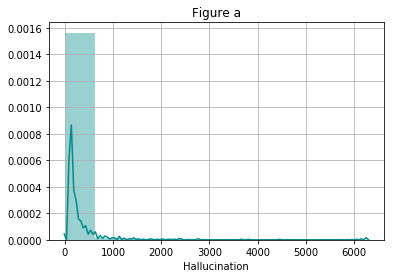

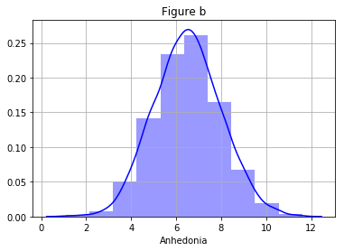

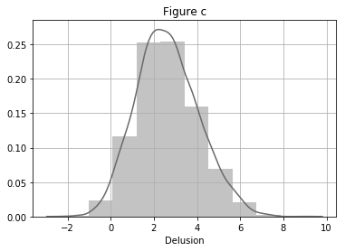

```python
# Distribution plot
sns.distplot(MS4S16_Dataset['Hallucination'], bins=10, color='DarkCyan')
plt.grid(True)
plt.title('Figure a')
plt.show()

sns.distplot(MS4S16_Dataset['Anhedonia'], bins=10, color='Blue')
plt.grid(True)
plt.title('Figure b')
plt.show()

sns.distplot(MS4S16_Dataset['Delusion'], bins=10, color='DimGrey')
plt.grid(True)
plt.title('Figure c')
plt.show()
```

## Histogram Plots

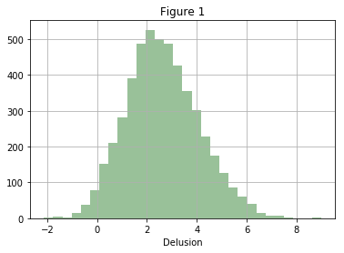

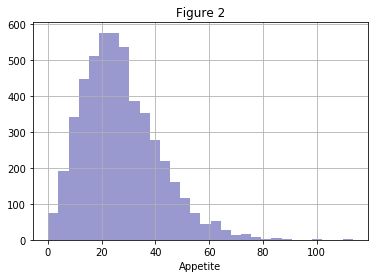

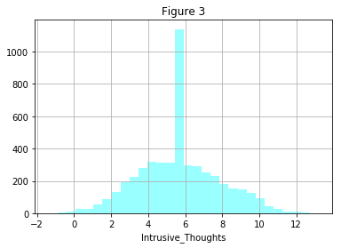

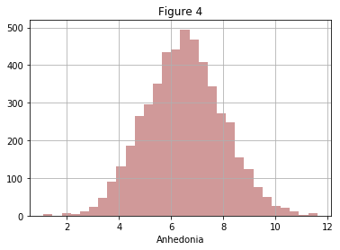

```python
# Some Histogram Plots

# histogram based on Delusion from the data given
sns.distplot(MS4S16_Dataset['Delusion'],bins=30,kde=False, color='darkgreen')
plt.grid(True)
plt.title('Figure 1')
plt.show()

# histogram based on Appetite from the data given
sns.distplot(MS4S16_Dataset['Appetite'],bins=30,kde=False, color='darkblue')
plt.grid(True)
plt.title('Figure 2')
plt.show()

# histogram based on Intrusive Thought from the data given
sns.distplot(MS4S16_Dataset['Intrusive_Thoughts'],bins=30,kde=False, color='cyan')
plt.grid(True)
plt.title('Figure 3')
plt.show()

# histogram based on Anhedonia from the data given
sns.distplot(MS4S16_Dataset['Anhedonia'],bins=30,kde=False, color='darkred')
plt.grid(True)
plt.title('Figure 4')
plt.show()
```

## Scatter plot analysis

The most crucial step in every machine intelligence project is data collection. The most typical types of data to collect are numerical and metric data. Data are frequently kept in arrays that show the relationship between values. In a scatter plot, points are dispersed throughout an area to show how two values relate to one another.

Scatter plots are used to show relationships. For correlation, scatter plots help show the strength of the linear relationship between two variables. For regression, scatter plots often add a fitted line

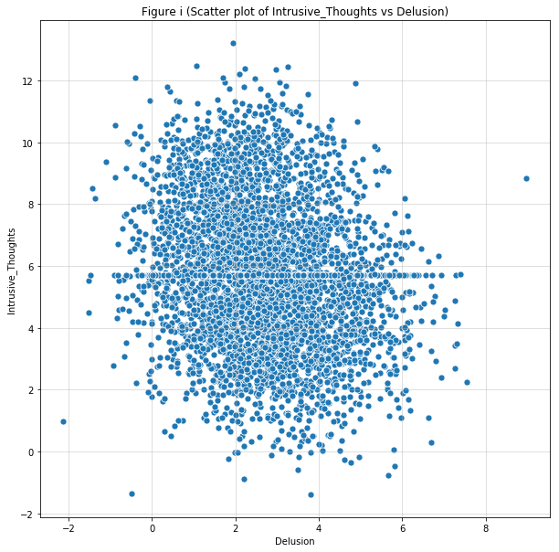

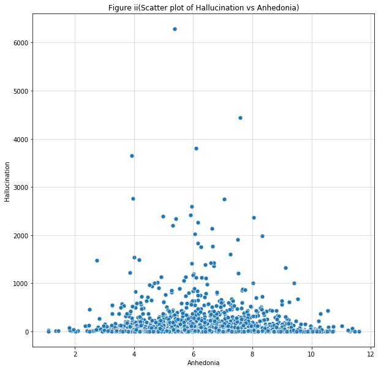

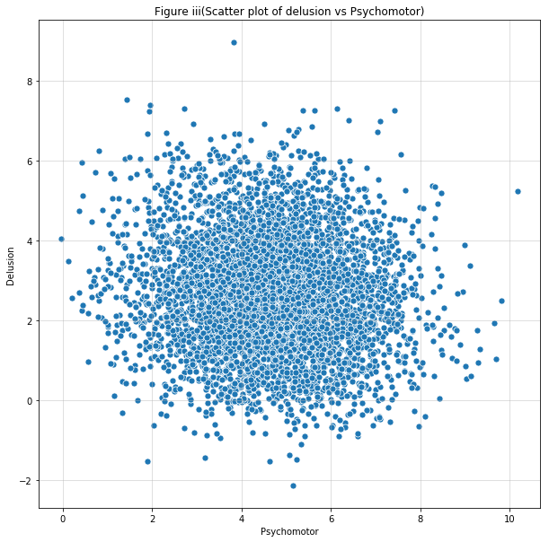

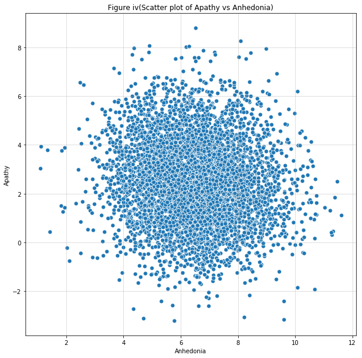

```python
# scatter plot delusion and intrusive plot
plt.figure(figsize=(10,10))
scatter_plot = sns.scatterplot(x='Delusion', y='Intrusive_Thoughts',data=MS4S16_Dataset, s=50)
plt.title('Figure i (Scatter plot of Intrusive_Thoughts vs Delusion)')
plt.grid(alpha=0.5)


# scatter plot Anhedonia and Hallucination plot
plt.figure(figsize=(10,10))
scatter_plot = sns.scatterplot(x='Anhedonia', y='Hallucination',data=MS4S16_Dataset, s=50)
plt.title('Figure ii(Scatter plot of Hallucination vs Anhedonia)')
plt.grid(alpha=0.5)

# scatter plot Anhedonia and Hallucination plot
plt.figure(figsize=(10,10))
scatter_plot = sns.scatterplot(x='Psychomotor', y='Delusion',data=MS4S16_Dataset, s=50)
plt.title('Figure iii(Scatter plot of delusion vs Psychomotor)')
plt.grid(alpha=0.5)

# scatter plot Anhedonia and Hallucination plot
plt.figure(figsize=(10,10))
scatter_plot = sns.scatterplot(x='Anhedonia', y='Apathy',data=MS4S16_Dataset, s=50)
plt.title('Figure iv(Scatter plot of Apathy vs Anhedonia)')
plt.grid(alpha=0.5)
```

In the Scatter plots above, that is Figure i - iv

We can see that we have no linear realtionships between the variables

## To get the skewness of the variables

In statistics, skewness is a measure of the probability distribution's asymmetry with respect to its mean and aids in describing the probability distribution's shape. In essence, it assesses how much a given distribution deviates from the normal distribution (which is symmetric)

Therefore, a curve is considered to be skewed if it is tilted to the right or left. Skewness gauges how far a random variable's distribution deviates from the symmetrical on both sides normal distribution. A distribution might have a left or right skewed distribution.

When the skewness parameter is negative, the distribution's tail is on the left side and leads to more negative values.

When skewness is positive, the tail of the distribution is on the right side and extends toward more positive values.

Any skewness in the distribution which is represented by a value of 0, which means the distribution is fully symmetrical.

using .skew()

```python
 MS4S16_Dataset.skew()
```

```
Diagnosis             -0.023209
Anhedonia              0.061404
Apathy                 0.150706
Appetite               0.852963
Concentration          0.012708
Content               10.551979
Delusion               0.271751
Dep_Mood              -0.821129
Focus                  0.012708
Hallucination         11.739268
Intrusive_Thoughts     0.144122
Participant            0.000000
Passive               -0.303510
Pregnant               3.863343
Psychomotor           -0.048500
Rumination             0.185656
Sleep                 -0.026453
Stress                -0.347927
Suspicious             0.256551
Tension               -0.479266
Tired                  0.081673
Unusual_Thought        0.240877
Withdrawal            -0.010129
dtype: float64
```

## Using One Hot Encoding

One hot encoding is a popular technique been used to classify data variables so that machine learning algorithms can use them to generate more accurate predictions. In one-hot encoding, each categorical value is transformed into a distinct column and assigned a binary value of either 0 or 1. A binary vector is represented by each integer value.

Using the get_dummies() from Pandas

```python
# get the dummies and store it in a variable
df1 = pd.get_dummies(MS4S16_Dataset['Race'])
df2 = pd.get_dummies(MS4S16_Dataset['Delay'])
df3 = pd.get_dummies(MS4S16_Dataset['Sex'])
df4 = pd.get_dummies(MS4S16_Dataset['Housing'])

# Concatenate the dummies to original dataframe
MS4S16_Dataset= pd.concat([MS4S16_Dataset, df1, df2, df3, df4], axis='columns')

# drop the values
MS4S16_Dataset.drop("Sex", axis=1, inplace=True)
MS4S16_Dataset.drop("Delay", axis=1, inplace=True)
MS4S16_Dataset.drop("Race", axis=1, inplace=True)
MS4S16_Dataset.drop("Housing", axis=1, inplace=True)

# Display the dataframe
MS4S16_Dataset
```

|  | Diagnosis | Anhedonia | Apathy | Appetite | Concentration | Content | Delusion | Dep_Mood | Focus | Hallucination | ... | Asian | Black | Hispanic | White | No | Yes | Female | Male | Stable | Unstable |
| --- | --- | --- | --- | --- | --- | --- | --- | --- | --- | --- | --- | --- | --- | --- | --- | --- | --- | --- | --- | --- | --- |
| 0 | 1 | 4.501446 | 3.056575 | 9.283891 | 8.305502 | 0.006142 | 1.170842 | 8.177884 | 8.305502 | 12.831823 | ... | 0 | 0 | 0 | 1 | 0 | 1 | 1 | 0 | 1 | 0 |
| 1 | 0 | 5.432608 | 0.307721 | 25.809400 | 5.060206 | 0.062209 | 2.272548 | 11.162913 | 5.060206 | 38.979963 | ... | 0 | 0 | 0 | 1 | 0 | 1 | 0 | 1 | 1 | 0 |
| 2 | 0 | 6.557500 | -1.412208 | 24.842012 | 6.504229 | 0.071532 | 1.439095 | 5.887363 | 6.504229 | 11.296530 | ... | 0 | 1 | 0 | 0 | 1 | 0 | 1 | 0 | 1 | 0 |
| 3 | 0 | 5.429568 | 1.686157 | 24.175853 | 6.994948 | 0.278345 | 1.380185 | 8.943851 | 6.994948 | 4.237368 | ... | 0 | 0 | 0 | 1 | 1 | 0 | 1 | 0 | 1 | 0 |
| 4 | 1 | 5.099846 | -0.612506 | 45.808490 | 5.869212 | 0.004214 | 1.237976 | 6.741627 | 5.869212 | 0.863636 | ... | 0 | 1 | 0 | 0 | 0 | 1 | 0 | 1 | 1 | 0 |
| 5 | 1 | 4.741820 | 5.249279 | 40.546297 | 6.304295 | 0.036026 | 3.367918 | 9.083414 | 6.304295 | 33.475702 | ... | 1 | 0 | 0 | 0 | 0 | 1 | 1 | 0 | 1 | 0 |
| 6 | 1 | 6.608759 | 3.136189 | 32.400421 | 5.519083 | 0.443484 | 4.001160 | 8.448621 | 5.519083 | 135.781470 | ... | 0 | 1 | 0 | 0 | 0 | 1 | 1 | 0 | 1 | 0 |
| 7 | 1 | 7.150700 | 3.416662 | 34.460302 | 8.355920 | 0.340528 | 2.862363 | 0.000000 | 8.355920 | 194.629219 | ... | 1 | 0 | 0 | 0 | 1 | 0 | 1 | 0 | 1 | 0 |
| 8 | 0 | 4.176741 | 2.296168 | 52.235631 | 5.509529 | 0.196207 | 0.274118 | 0.000000 | 5.509529 | 0.882506 | ... | 0 | 0 | 1 | 0 | 0 | 1 | 1 | 0 | 1 | 0 |
| 9 | 0 | 5.185233 | 2.891209 | 26.396848 | 3.490360 | 0.003706 | 2.839490 | 8.656884 | 3.490360 | 4.894669 | ... | 0 | 0 | 1 | 0 | 0 | 1 | 1 | 0 | 1 | 0 |
| 10 | 1 | 8.060203 | 4.995976 | 23.559857 | 7.569503 | 0.037921 | 1.439270 | 3.482523 | 7.569503 | 5.038267 | ... | 0 | 0 | 1 | 0 | 0 | 1 | 0 | 1 | 1 | 0 |
| 11 | 1 | 6.752766 | 1.970964 | 42.217354 | 7.695459 | 0.032136 | 2.950428 | 0.000000 | 7.695459 | 90.298715 | ... | 0 | 0 | 0 | 1 | 1 | 0 | 0 | 1 | 1 | 0 |
| 12 | 0 | 8.745443 | 2.110826 | 41.402504 | 4.600058 | 0.150450 | 1.523567 | 11.323310 | 4.600058 | 0.996367 | ... | 1 | 0 | 0 | 0 | 1 | 0 | 0 | 1 | 1 | 0 |
| 13 | 0 | 9.095487 | 2.092819 | 20.793348 | 4.334576 | 0.147777 | 3.428896 | 9.392531 | 4.334576 | 78.156853 | ... | 0 | 0 | 1 | 0 | 1 | 0 | 1 | 0 | 1 | 0 |
| 14 | 0 | 7.122978 | -0.274233 | 23.984754 | 3.960052 | 0.018161 | 2.492150 | 6.540927 | 3.960052 | 9.355031 | ... | 0 | 0 | 1 | 0 | 0 | 1 | 1 | 0 | 1 | 0 |
| 15 | 1 | 7.246154 | 3.574174 | 3.675811 | 7.512099 | 0.002079 | 2.218384 | 7.177058 | 7.512099 | 49.927781 | ... | 0 | 1 | 0 | 0 | 0 | 1 | 1 | 0 | 1 | 0 |
| 16 | 0 | 6.553485 | 2.792001 | 18.537699 | 7.528801 | 0.939528 | 2.406530 | 8.089492 | 7.528801 | 27.857104 | ... | 0 | 0 | 0 | 1 | 0 | 1 | 0 | 1 | 1 | 0 |
| 17 | 1 | 5.953953 | 4.479288 | 17.535036 | 7.630108 | 0.093171 | 5.933476 | 8.374044 | 7.630108 | 229.056373 | ... | 0 | 0 | 0 | 1 | 0 | 1 | 0 | 1 | 1 | 0 |
| 18 | 1 | 5.452113 | 0.739006 | 5.224380 | 9.105690 | 0.016825 | 3.004196 | 8.043615 | 9.105690 | 23.772122 | ... | 0 | 0 | 0 | 1 | 0 | 1 | 1 | 0 | 1 | 0 |
| 19 | 0 | 4.228123 | 0.905521 | 15.879692 | 5.572261 | 0.597682 | 0.504865 | 6.215001 | 5.572261 | 3.205477 | ... | 0 | 1 | 0 | 0 | 1 | 0 | 1 | 0 | 1 | 0 |
| 20 | 0 | 8.433511 | 3.246017 | 17.852691 | 8.008901 | 0.010824 | 1.343160 | 8.716224 | 8.008901 | 7.923317 | ... | 1 | 0 | 0 | 0 | 0 | 1 | 0 | 1 | 1 | 0 |
| 21 | 0 | 7.877249 | 2.037046 | 16.962552 | 5.276860 | 0.116928 | 4.406413 | 6.652407 | 5.276860 | 56.805588 | ... | 1 | 0 | 0 | 0 | 1 | 0 | 0 | 1 | 1 | 0 |
| 22 | 0 | 9.964745 | 1.417324 | 3.212219 | 7.752039 | 0.273541 | 3.682216 | 5.462605 | 7.752039 | 88.313518 | ... | 0 | 1 | 0 | 0 | 0 | 1 | 1 | 0 | 1 | 0 |
| 23 | 1 | 6.849099 | 3.505499 | 55.822219 | 7.086283 | 0.014957 | 1.771963 | 8.513921 | 7.086283 | 1.517530 | ... | 0 | 0 | 0 | 1 | 0 | 1 | 1 | 0 | 1 | 0 |
| 24 | 0 | 5.367756 | 1.849141 | 22.420123 | 5.610663 | 0.013150 | 2.394097 | 5.480421 | 5.610663 | 22.909561 | ... | 0 | 0 | 0 | 1 | 1 | 0 | 0 | 1 | 1 | 0 |
| 25 | 1 | 5.398893 | 5.668140 | 35.298660 | 8.831141 | 0.014926 | 2.668686 | 6.836210 | 8.831141 | 52.144623 | ... | 0 | 1 | 0 | 0 | 0 | 1 | 1 | 0 | 1 | 0 |
| 26 | 0 | 6.094305 | 2.784335 | 33.858224 | 5.220698 | 0.012199 | 2.782884 | 0.000000 | 5.220698 | 11.523895 | ... | 0 | 0 | 1 | 0 | 0 | 1 | 0 | 1 | 1 | 0 |
| 27 | 0 | 7.082530 | 2.261606 | 48.739883 | 6.777505 | 0.026424 | 1.778631 | 9.424249 | 6.777505 | 14.244918 | ... | 0 | 0 | 0 | 1 | 1 | 0 | 1 | 0 | 1 | 0 |
| 28 | 1 | 4.224259 | 2.564913 | 39.480308 | 8.213267 | 0.299862 | 4.522135 | 8.075621 | 8.213267 | 38.046430 | ... | 0 | 0 | 0 | 1 | 0 | 1 | 1 | 0 | 1 | 0 |
| 29 | 0 | 7.700608 | 0.636408 | 36.761309 | 5.370435 | 0.083866 | -0.627327 | 7.093312 | 5.370435 | 0.792399 | ... | 0 | 1 | 0 | 0 | 1 | 0 | 0 | 1 | 1 | 0 |
| ... | ... | ... | ... | ... | ... | ... | ... | ... | ... | ... | ... | ... | ... | ... | ... | ... | ... | ... | ... | ... | ... |
| 4970 | 1 | 6.322317 | 1.932337 | 30.310831 | 6.926281 | 0.001125 | 1.074066 | 6.732615 | 6.926281 | 0.909891 | ... | 1 | 0 | 0 | 0 | 0 | 1 | 1 | 0 | 1 | 0 |
| 4971 | 1 | 4.932279 | 3.115098 | 26.627377 | 8.766304 | 0.026915 | 3.001095 | 0.000000 | 8.766304 | 37.037952 | ... | 1 | 0 | 0 | 0 | 0 | 1 | 0 | 1 | 1 | 0 |
| 4972 | 0 | 7.969933 | 5.356544 | 9.005683 | 6.230924 | 0.010370 | 3.753997 | 0.000000 | 6.230924 | 119.818515 | ... | 0 | 0 | 0 | 1 | 1 | 0 | 1 | 0 | 1 | 0 |
| 4973 | 0 | 8.052007 | 0.245599 | 32.673282 | 5.677884 | 0.023099 | 2.543267 | 7.363887 | 5.677884 | 24.323715 | ... | 0 | 1 | 0 | 0 | 1 | 0 | 1 | 0 | 1 | 0 |
| 4974 | 1 | 7.532437 | 3.809152 | 7.476118 | 3.906331 | 0.038924 | 2.296658 | 6.834889 | 3.906331 | 8.800563 | ... | 0 | 1 | 0 | 0 | 0 | 1 | 1 | 0 | 0 | 1 |
| 4975 | 1 | 5.821762 | 2.751301 | 15.125588 | 6.935933 | 0.055483 | 2.338316 | 5.859163 | 6.935933 | 5.433910 | ... | 0 | 1 | 0 | 0 | 0 | 1 | 0 | 1 | 1 | 0 |
| 4976 | 0 | 6.618214 | 3.114161 | 72.509868 | 7.688757 | 0.204873 | 1.860521 | 8.799597 | 7.688757 | 4.368956 | ... | 0 | 0 | 1 | 0 | 0 | 1 | 0 | 1 | 1 | 0 |
| 4977 | 0 | 8.947034 | 2.657104 | 27.867260 | 7.189758 | 0.073078 | 1.457279 | 6.959514 | 7.189758 | 5.309877 | ... | 0 | 1 | 0 | 0 | 1 | 0 | 1 | 0 | 1 | 0 |
| 4978 | 0 | 6.487598 | 3.293639 | 9.920659 | 3.980330 | 0.183186 | 1.610488 | 7.627560 | 3.980330 | 11.530296 | ... | 1 | 0 | 0 | 0 | 1 | 0 | 1 | 0 | 1 | 0 |
| 4979 | 0 | 7.175628 | 1.147763 | 27.945838 | 9.495171 | 0.080938 | 4.211235 | 0.000000 | 9.495171 | 293.766643 | ... | 0 | 1 | 0 | 0 | 0 | 1 | 1 | 0 | 1 | 0 |
| 4980 | 0 | 6.553685 | 1.846938 | 55.561731 | 7.462806 | 0.070935 | 1.593259 | 4.751636 | 7.462806 | 24.134796 | ... | 0 | 1 | 0 | 0 | 0 | 1 | 1 | 0 | 1 | 0 |
| 4981 | 1 | 4.895836 | 8.080668 | 8.946832 | 7.681086 | 0.053206 | 3.960946 | 5.554169 | 7.681086 | 225.693820 | ... | 0 | 0 | 0 | 1 | 0 | 1 | 0 | 1 | 1 | 0 |
| 4982 | 0 | 6.415584 | 2.697319 | 34.913531 | 8.548397 | 0.017608 | 2.506987 | 0.000000 | 8.548397 | 49.196133 | ... | 0 | 0 | 1 | 0 | 1 | 0 | 0 | 1 | 1 | 0 |
| 4983 | 0 | 7.199459 | 2.224966 | 69.941235 | 6.599882 | 0.585097 | 3.682006 | 0.000000 | 6.599882 | 24.549077 | ... | 0 | 1 | 0 | 0 | 1 | 0 | 1 | 0 | 1 | 0 |
| 4984 | 0 | 9.486103 | 4.579750 | 17.984760 | 6.830462 | 0.020477 | 1.089651 | 0.000000 | 6.830462 | 4.632150 | ... | 0 | 1 | 0 | 0 | 1 | 0 | 1 | 0 | 1 | 0 |
| 4985 | 0 | 6.026825 | 0.052504 | 40.865273 | 6.830011 | 0.024636 | 3.251588 | 0.000000 | 6.830011 | 7.377757 | ... | 1 | 0 | 0 | 0 | 1 | 0 | 1 | 0 | 1 | 0 |
| 4986 | 1 | 7.695504 | 1.363324 | 24.794283 | 5.590045 | 0.022720 | 5.687095 | 9.301858 | 5.590045 | 133.892757 | ... | 0 | 1 | 0 | 0 | 1 | 0 | 0 | 1 | 1 | 0 |
| 4987 | 1 | 8.196214 | 4.029129 | 24.433703 | 6.379029 | 0.195270 | 3.076325 | 5.431605 | 6.379029 | 1.590095 | ... | 0 | 1 | 0 | 0 | 1 | 0 | 1 | 0 | 1 | 0 |
| 4988 | 1 | 6.416485 | 5.799854 | 44.367986 | 4.724929 | 0.001452 | 1.248973 | 5.660038 | 4.724929 | 2.218102 | ... | 0 | 0 | 0 | 1 | 1 | 0 | 1 | 0 | 1 | 0 |
| 4989 | 1 | 7.500406 | 2.992234 | 19.690583 | 4.897845 | 0.051666 | 4.020461 | 0.000000 | 4.897845 | 71.547942 | ... | 0 | 0 | 1 | 0 | 1 | 0 | 1 | 0 | 1 | 0 |
| 4990 | 0 | 6.062274 | 1.454241 | 34.275149 | 6.907768 | 0.146706 | 1.736306 | 0.000000 | 6.907768 | 10.790598 | ... | 1 | 0 | 0 | 0 | 1 | 0 | 0 | 1 | 1 | 0 |
| 4991 | 0 | 7.002544 | 3.378921 | 46.700975 | 3.275995 | 0.022957 | 1.108537 | 0.000000 | 3.275995 | 0.745422 | ... | 1 | 0 | 0 | 0 | 0 | 1 | 1 | 0 | 1 | 0 |
| 4992 | 0 | 10.705854 | 1.165093 | 18.861853 | 7.806327 | 3.765075 | 0.380176 | 9.242844 | 7.806327 | 0.374872 | ... | 0 | 1 | 0 | 0 | 1 | 0 | 1 | 0 | 1 | 0 |
| 4993 | 1 | 5.698281 | 3.502564 | 21.513402 | 8.209253 | 0.046388 | 2.754629 | 0.000000 | 8.209253 | 35.675687 | ... | 0 | 1 | 0 | 0 | 1 | 0 | 1 | 0 | 1 | 0 |
| 4994 | 1 | 3.115041 | 4.283234 | 10.783892 | 6.793542 | 0.871349 | 2.571130 | 0.000000 | 6.793542 | 13.061437 | ... | 0 | 1 | 0 | 0 | 0 | 1 | 1 | 0 | 1 | 0 |
| 4995 | 0 | 7.860754 | 2.336196 | 19.357732 | 6.025528 | 0.010833 | 1.943012 | 10.131561 | 6.025528 | 8.580963 | ... | 0 | 0 | 1 | 0 | 0 | 1 | 1 | 0 | 1 | 0 |
| 4996 | 0 | 10.172056 | 1.385703 | 12.605660 | 4.513683 | 0.191444 | 0.443218 | 6.935870 | 4.513683 | 0.366549 | ... | 0 | 1 | 0 | 0 | 0 | 1 | 1 | 0 | 1 | 0 |
| 4997 | 1 | 4.880272 | 0.311701 | 39.005728 | 6.817671 | 0.003989 | 3.770044 | 5.107938 | 6.817671 | 60.747235 | ... | 0 | 1 | 0 | 0 | 0 | 1 | 0 | 1 | 1 | 0 |
| 4998 | 1 | 7.288783 | 4.135178 | 38.522660 | 7.611236 | 0.123641 | 0.703623 | 5.528039 | 7.611236 | 5.133514 | ... | 1 | 0 | 0 | 0 | 1 | 0 | 1 | 0 | 1 | 0 |
| 4999 | 1 | 7.170936 | 2.391218 | 44.282062 | 6.562269 | 0.190619 | 3.937267 | 5.546932 | 6.562269 | 116.326200 | ... | 1 | 0 | 0 | 0 | 1 | 0 | 1 | 0 | 1 | 0 |

5000 rows × 33 columns

## Assigning variables to X and y

```python
# Assigning variables X and y.

X = MS4S16_Dataset.drop(['Diagnosis'],axis=1)
y = MS4S16_Dataset['Diagnosis']
```

After assigning variables X and y, we noticed some infinity in the values of X with column named 'Tired' from the skewness We can continue with our analysis

## K-means clustering

Data can be divided into groups, or clusters, using a variety of processes called clustering. In a broad sense, clusters are collections of data objects that share more similarities with one another than with those in other clusters. In actuality, clustering aids in spotting two characteristics of data:

a)Meaningfulness b)Usefulness a)Domain knowledge is expanded by meaningful clusters. For instance, scientists used clustering in gene expression studies in the medical field. The clustering findings revealed patient populations that react differentially to medicinal interventions.

b)On the other hand, useful clusters act as a middle stage in a data pipeline. Businesses, for instance, employ clustering to categorise their clientele. Customers are divided into categories based on their clustering findings, which firms can utilise to generate targeted advertising campaigns.

One of the most straightforward and well-known unsupervised learning algorithms called k-means clustering is used to find groups of data objects in a dataset. Although there are many alternative clustering techniques, k-means is one of the most established and user-friendly. These characteristics make k-means clustering in Python relatively simple to implement, even for inexperienced programmers and data scientists.

In general, clustering groups cases in a dataset into clusters with similar properties using iterative procedures. These classifications can be used to explore data, spot abnormalities, and finally make predictions. Additionally, clustering models can assist you in finding connections in a dataset that browsing or straightforward observation might not logically reveal. In the beginning stages of machine learning projects, clustering is frequently used to explore the data and find unexpected correlations.

```python
from sklearn.preprocessing import MinMaxScaler
min_max_scaler = MinMaxScaler()
X_scaled = min_max_scaler.fit_transform(X)
```

```python
from sklearn.decomposition import PCA
pca = PCA(2)

#Transform the data
X_pca = pca.fit_transform(X_scaled)

X_pca.shape
```

```
(5000, 2)
```

In order to illustrate the results using a 2D Scatter plot, we applied PCA to minimise the number of dimensions.

```python
from sklearn.cluster import KMeans
Kmeans = KMeans(n_clusters=4)
Kmeans.fit(X_pca)
```

```
KMeans(algorithm='auto', copy_x=True, init='k-means++', max_iter=300,
    n_clusters=4, n_init=10, n_jobs=None, precompute_distances='auto',
    random_state=None, tol=0.0001, verbose=0)
```

```python
y_pred = Kmeans.predict(X_pca)
```

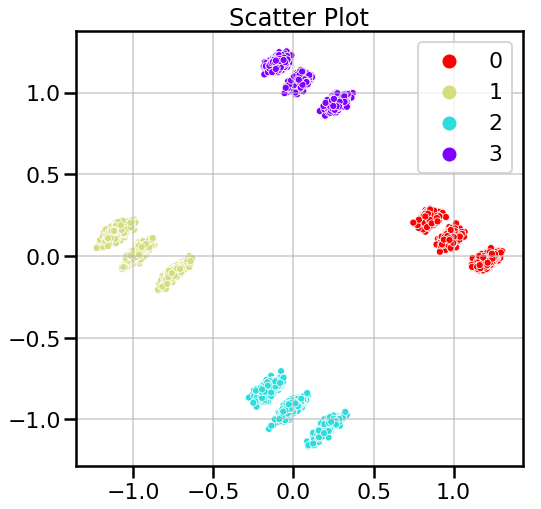

```python
plt.figure(figsize=(8,8))
sns.set_context('poster')
sns.scatterplot(data=None, x=X_pca[:,0],
               y=X_pca[:,1],
               hue = y_pred,
               palette = 'rainbow_r', s=50)
plt.title('Scatter Plot')
plt.grid(alpha = 0.5)
```

```python
# Calculation the Inertia
from sklearn.cluster import KMeans

inertia = []
for i in range (2,20):
    Kmeans = KMeans(n_clusters=i)
    Kmeans.fit(X_pca)
    inertia.append(Kmeans.inertia_)
print(inertia)
```

```
[2583.3035480068934, 1299.6556991819734, 184.13192254928592, 140.40191967351743, 100.51926469711456, 63.843828576075026, 38.280604438012375, 29.7072050209401, 22.374935124945218, 17.09363722708742, 11.904947623973012, 10.89786473098914, 10.238076798274486, 9.303248374078233, 8.550049164296693, 7.914…
```

The mean square distance between each instance and its nearest centroid, which is an attribute of our k-means object, is called inertia.

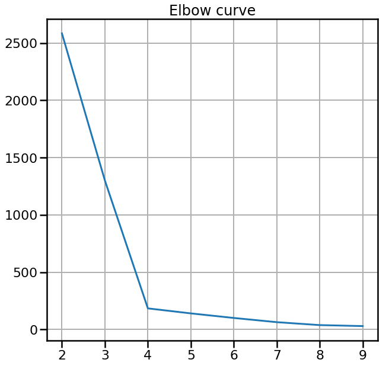

```python
#Checking for the elbow curve
X = X_pca
distorsions = []
for k in range(2, 10):
    kmeans = KMeans(n_clusters=k)
    kmeans.fit(X)
    distorsions.append(kmeans.inertia_)

fig = plt.figure(figsize=(10, 10))
plt.plot(range(2, 10), distorsions)
plt.grid(True)
plt.title('Elbow curve')
```

From the elbow Curve,we can see that the best cluster(k) to use should be four(4)

```python
#To show the silhouette_scores from 2 to 10 of the cluster
from sklearn.cluster import KMeans
from sklearn.metrics import silhouette_score

silhouette_scores = []

for i in range(2, 10):
    Kmeans = KMeans(n_clusters=i)
    Kmeans.fit(X_pca)
    silhouette_scores.append(silhouette_score(X_pca,
                                              Kmeans.labels_))

print(silhouette_scores)
```

```
[0.5385218170122488, 0.6576527220645434, 0.8297984982130798, 0.8091535534804187, 0.7571047093408702, 0.7271133100969173, 0.7055344990084336, 0.7113805324945459]
```

The silhouette score measures how effectively samples are clustered with other samples that are similar to them in order to assess the quality of clusters produced by clustering algorithms like K-Means. Each sample of various clusters receives a Silhouette score.

The cluster with the best score close to +1 will be the best cluster

```
However,we can see that the cluster with the best score is four(4), with 0.8297984983395552
```

Now,we have

```python
from sklearn.cluster import KMeans
from sklearn.metrics import silhouette_score

silhouette_scores = []

Kmeans = KMeans(n_clusters=4)
Kmeans.fit(X_pca)
silhouette_scores.append(silhouette_score(X_pca,
                                          Kmeans.labels_))

print(silhouette_scores)
```

```
[0.8297984982130798]
```

The silhouette score measure for the cluster when k=4 is 0.8297984983395552

## Splitting of the Data Set

## Training and Test test

```python
# Assigning variables X and y.

X = MS4S16_Dataset.drop(['Diagnosis'],axis=1)
y = MS4S16_Dataset['Diagnosis']
```

```python
# Performing the test-train split, setting apart 25% of the dataset for thr test set
# This creates new variables , the training set and the test sets for variable x and y

X_train, X_test, y_train, y_test = train_test_split(X, y, test_size=0.25, random_state=0)
```

```python
X_train
```

|  | Anhedonia | Apathy | Appetite | Concentration | Content | Delusion | Dep_Mood | Focus | Hallucination | Intrusive_Thoughts | ... | Asian | Black | Hispanic | White | No | Yes | Female | Male | Stable | Unstable |
| --- | --- | --- | --- | --- | --- | --- | --- | --- | --- | --- | --- | --- | --- | --- | --- | --- | --- | --- | --- | --- | --- |
| 4154 | 7.370166 | 3.827752 | 26.413294 | 6.366356 | 0.002123 | 3.279084 | 7.155150 | 6.366356 | 6.948127 | 2.223810 | ... | 0 | 0 | 0 | 1 | 1 | 0 | 1 | 0 | 0 | 1 |
| 4820 | 8.157966 | 3.146191 | 15.082487 | 4.830909 | 0.823835 | 0.953193 | 6.197900 | 4.830909 | 0.309714 | 5.787045 | ... | 0 | 1 | 0 | 0 | 1 | 0 | 1 | 0 | 1 | 0 |
| 1202 | 9.492426 | 3.765191 | 39.948250 | 6.774377 | 0.067579 | 0.796962 | 0.000000 | 6.774377 | 9.032034 | 5.218368 | ... | 0 | 1 | 0 | 0 | 0 | 1 | 1 | 0 | 1 | 0 |
| 3759 | 5.028754 | 2.110104 | 15.948347 | 6.097250 | 0.061872 | -0.019023 | 0.000000 | 6.097250 | 2.195735 | 3.000390 | ... | 0 | 0 | 0 | 1 | 1 | 0 | 0 | 1 | 1 | 0 |
| 622 | 8.242525 | 2.657022 | 18.000028 | 7.078333 | 0.096736 | 1.943358 | 7.075686 | 7.078333 | 2.350651 | 1.908509 | ... | 0 | 0 | 1 | 0 | 0 | 1 | 0 | 1 | 1 | 0 |
| 4365 | 4.881071 | 3.248394 | 8.771912 | 6.022252 | 0.080514 | 3.258459 | 0.000000 | 6.022252 | 40.028975 | 5.315102 | ... | 0 | 0 | 0 | 1 | 0 | 1 | 1 | 0 | 1 | 0 |
| 1457 | 6.909862 | 2.318994 | 43.688290 | 6.225625 | 2.682091 | 2.225098 | 7.100059 | 6.225625 | 23.570977 | 6.897316 | ... | 0 | 0 | 1 | 0 | 1 | 0 | 1 | 0 | 1 | 0 |
| 2058 | 7.111553 | 2.166749 | 26.647059 | 6.292842 | 0.074033 | 2.826801 | 0.000000 | 6.292842 | 10.575900 | 7.076705 | ... | 0 | 0 | 1 | 0 | 1 | 0 | 1 | 0 | 1 | 0 |
| 2078 | 7.177654 | -0.930429 | 49.203613 | 6.676751 | 0.027081 | 1.578552 | 9.218790 | 6.676751 | 2.616609 | 9.156703 | ... | 1 | 0 | 0 | 0 | 1 | 0 | 1 | 0 | 1 | 0 |
| 1536 | 7.598206 | 1.960535 | 25.857630 | 5.468456 | 1.983900 | -0.018165 | 6.604840 | 5.468456 | 0.617576 | 1.767981 | ... | 1 | 0 | 0 | 0 | 1 | 0 | 0 | 1 | 1 | 0 |
| 1642 | 8.597890 | 0.379580 | 34.474209 | 4.749243 | 0.505531 | 1.377705 | 8.194502 | 4.749243 | 8.821271 | 4.137884 | ... | 0 | 0 | 0 | 1 | 1 | 0 | 0 | 1 | 1 | 0 |
| 2215 | 4.704533 | 5.466158 | 29.482096 | 4.647501 | 0.006962 | 3.961311 | 6.958652 | 4.647501 | 16.827524 | 4.101725 | ... | 0 | 1 | 0 | 0 | 0 | 1 | 0 | 1 | 1 | 0 |
| 2863 | 5.784560 | 3.686714 | 20.162380 | 8.149516 | 0.035098 | 4.179826 | 8.769885 | 8.149516 | 32.039772 | 5.779243 | ... | 0 | 0 | 0 | 1 | 1 | 0 | 0 | 1 | 1 | 0 |
| 3349 | 6.756584 | 0.256563 | 16.977569 | 4.897166 | 0.082475 | -0.476475 | 5.431740 | 4.897166 | 0.055778 | 5.044566 | ... | 0 | 1 | 0 | 0 | 0 | 1 | 1 | 0 | 1 | 0 |
| 3374 | 6.679311 | 1.332078 | 22.904437 | 5.463270 | 0.104896 | 3.578115 | 7.657459 | 5.463270 | 7.454933 | 8.530620 | ... | 0 | 1 | 0 | 0 | 1 | 0 | 1 | 0 | 1 | 0 |
| 4689 | 7.703312 | 2.154540 | 52.468111 | 5.432979 | 0.068554 | 1.464807 | 0.000000 | 5.432979 | 3.288183 | 2.300153 | ... | 0 | 1 | 0 | 0 | 0 | 1 | 0 | 1 | 1 | 0 |
| 3287 | 4.122861 | 1.949245 | 44.788904 | 8.133373 | 0.104758 | 3.927107 | 0.000000 | 8.133373 | 16.874381 | 3.730603 | ... | 0 | 0 | 0 | 1 | 0 | 1 | 1 | 0 | 1 | 0 |
| 3687 | 6.887918 | -0.621657 | 58.687551 | 5.655700 | 0.318210 | 1.314946 | 9.373714 | 5.655700 | 8.347510 | 6.340991 | ... | 0 | 0 | 0 | 1 | 0 | 1 | 0 | 1 | 1 | 0 |
| 408 | 5.984700 | 0.217994 | 24.456293 | 3.838652 | 0.077913 | 1.798756 | 0.000000 | 3.838652 | 1.207310 | 4.390352 | ... | 1 | 0 | 0 | 0 | 1 | 0 | 0 | 1 | 1 | 0 |
| 4753 | 7.043909 | 1.570358 | 50.692330 | 5.924465 | 0.002447 | 1.961717 | 5.036758 | 5.924465 | 1.053599 | 2.742805 | ... | 0 | 1 | 0 | 0 | 0 | 1 | 0 | 1 | 1 | 0 |
| 1376 | 8.410071 | 0.658854 | 23.525085 | 2.394830 | 0.322013 | 4.171290 | 5.485705 | 2.394830 | 23.958498 | 6.686944 | ... | 0 | 0 | 0 | 1 | 0 | 1 | 1 | 0 | 1 | 0 |
| 1077 | 8.295750 | 0.700717 | 26.080758 | 6.925650 | 0.029335 | 1.829969 | 6.397479 | 6.925650 | 20.097324 | 10.568195 | ... | 0 | 0 | 0 | 1 | 0 | 1 | 1 | 0 | 1 | 0 |
| 1515 | 6.004026 | 2.204431 | 25.096828 | 8.379879 | 0.007031 | 2.027357 | 7.621486 | 8.379879 | 3.473080 | 6.162823 | ... | 0 | 1 | 0 | 0 | 1 | 0 | 0 | 1 | 1 | 0 |
| 1926 | 7.386550 | 1.258100 | 44.120447 | 9.053704 | 0.131889 | 1.392971 | 6.739796 | 9.053704 | 1.844400 | 10.332029 | ... | 0 | 0 | 0 | 1 | 1 | 0 | 1 | 0 | 1 | 0 |
| 4708 | 7.809933 | 1.784707 | 27.333668 | 5.132781 | 1.295272 | 2.591972 | 7.548610 | 5.132781 | 8.728749 | 11.734597 | ... | 0 | 0 | 0 | 1 | 1 | 0 | 1 | 0 | 0 | 1 |
| 2669 | 5.135060 | 1.248720 | 26.269983 | 7.196066 | 0.150252 | 0.268697 | 9.411600 | 7.196066 | 6.274977 | 5.663857 | ... | 0 | 0 | 1 | 0 | 1 | 0 | 1 | 0 | 0 | 1 |
| 4598 | 5.202102 | 4.992887 | 37.935999 | 7.947926 | 0.005518 | 5.115289 | 8.044007 | 7.947926 | 65.199898 | 2.825664 | ... | 0 | 1 | 0 | 0 | 1 | 0 | 0 | 1 | 1 | 0 |
| 1256 | 4.800677 | 0.448306 | 9.370357 | 4.543207 | 0.061586 | 2.194567 | 0.000000 | 4.543207 | 18.393974 | 7.368920 | ... | 0 | 0 | 0 | 1 | 1 | 0 | 0 | 1 | 0 | 1 |
| 429 | 4.405588 | -0.033921 | 20.391904 | 5.667712 | 0.056733 | 3.609064 | 7.426215 | 5.667712 | 56.660867 | 3.101616 | ... | 0 | 1 | 0 | 0 | 1 | 0 | 1 | 0 | 1 | 0 |
| 4894 | 4.735700 | 3.313716 | 40.555947 | 6.749657 | 0.293891 | 4.400975 | 8.678384 | 6.749657 | 185.726358 | 8.148613 | ... | 0 | 0 | 0 | 1 | 1 | 0 | 1 | 0 | 0 | 1 |
| ... | ... | ... | ... | ... | ... | ... | ... | ... | ... | ... | ... | ... | ... | ... | ... | ... | ... | ... | ... | ... | ... |
| 3337 | 4.780202 | 2.336501 | 30.527433 | 6.368936 | 0.046210 | 4.263444 | 8.257016 | 6.368936 | 53.004993 | 4.825256 | ... | 0 | 0 | 1 | 0 | 1 | 0 | 1 | 0 | 1 | 0 |
| 423 | 6.419633 | 7.094504 | 25.434610 | 6.120208 | 0.237250 | 2.727212 | 6.984432 | 6.120208 | 6.664829 | 5.702358 | ... | 0 | 0 | 0 | 1 | 1 | 0 | 1 | 0 | 1 | 0 |
| 3219 | 6.480082 | 1.206093 | 10.587944 | 5.932737 | 0.029091 | 4.033546 | 5.478511 | 5.932737 | 6.151291 | 7.202651 | ... | 0 | 1 | 0 | 0 | 1 | 0 | 1 | 0 | 1 | 0 |
| 659 | 5.976025 | 3.585899 | 26.224017 | 5.212811 | 0.405458 | -0.635545 | 9.422828 | 5.212811 | 0.301197 | 5.649418 | ... | 1 | 0 | 0 | 0 | 1 | 0 | 0 | 1 | 1 | 0 |
| 797 | 6.975709 | 2.427353 | 25.324768 | 5.322966 | 0.024577 | -0.405579 | 9.252975 | 5.322966 | 0.484702 | 7.288833 | ... | 0 | 0 | 0 | 1 | 1 | 0 | 1 | 0 | 1 | 0 |
| 755 | 5.842904 | 4.947534 | 25.882220 | 5.641958 | 0.019026 | 0.749658 | 0.000000 | 5.641958 | 0.532236 | 4.994120 | ... | 0 | 1 | 0 | 0 | 1 | 0 | 1 | 0 | 1 | 0 |
| 2008 | 8.205214 | 0.853791 | 8.724696 | 5.988541 | 0.106162 | 2.153825 | 8.767978 | 5.988541 | 11.181389 | 3.144483 | ... | 0 | 1 | 0 | 0 | 1 | 0 | 0 | 1 | 1 | 0 |
| 99 | 6.174373 | 2.314974 | 64.139912 | 4.950651 | 0.002061 | 3.020228 | 8.527824 | 4.950651 | 34.878883 | 3.819094 | ... | 0 | 1 | 0 | 0 | 0 | 1 | 0 | 1 | 1 | 0 |
| 2496 | 3.647580 | 3.254672 | 24.943370 | 8.027031 | 0.130482 | 3.742881 | 8.028314 | 8.027031 | 25.404781 | 6.361919 | ... | 1 | 0 | 0 | 0 | 0 | 1 | 1 | 0 | 1 | 0 |
| 1871 | 7.425671 | 2.833624 | 47.175174 | 6.136520 | 0.035189 | 2.361416 | 7.635879 | 6.136520 | 12.986584 | 5.109859 | ... | 0 | 0 | 0 | 1 | 1 | 0 | 0 | 1 | 0 | 1 |
| 2046 | 6.913462 | 1.422419 | 29.719478 | 7.196070 | 0.048952 | 1.408123 | 9.923027 | 7.196070 | 2.695992 | 4.959618 | ... | 0 | 0 | 0 | 1 | 0 | 1 | 0 | 1 | 1 | 0 |
| 4851 | 6.981300 | 2.933585 | 40.831288 | 7.451755 | 0.009712 | 0.531158 | 0.000000 | 7.451755 | 0.481291 | 3.525380 | ... | 0 | 1 | 0 | 0 | 0 | 1 | 0 | 1 | 1 | 0 |
| 2163 | 6.463259 | 0.290893 | 16.862532 | 5.420476 | 0.090732 | 1.334267 | 9.591752 | 5.420476 | 1.191923 | 4.869849 | ... | 1 | 0 | 0 | 0 | 1 | 0 | 0 | 1 | 1 | 0 |
| 2893 | 4.365294 | -0.367868 | 18.530173 | 6.021282 | 0.048985 | 2.361121 | 9.354180 | 6.021282 | 35.505943 | 4.230836 | ... | 0 | 1 | 0 | 0 | 1 | 0 | 0 | 1 | 1 | 0 |
| 537 | 5.932019 | 1.045722 | 56.369957 | 7.403522 | 0.033009 | 2.733620 | 7.747923 | 7.403522 | 6.820231 | 4.780154 | ... | 0 | 1 | 0 | 0 | 1 | 0 | 0 | 1 | 1 | 0 |
| 1701 | 8.767879 | 3.179259 | 10.793236 | 4.888731 | 0.020007 | 1.306771 | 8.510994 | 4.888731 | 2.675173 | 7.571352 | ... | 1 | 0 | 0 | 0 | 1 | 0 | 1 | 0 | 1 | 0 |
| 2897 | 7.974826 | 5.155264 | 23.752953 | 6.865642 | 0.046357 | 1.886415 | 0.000000 | 6.865642 | 1.959418 | 4.238783 | ... | 0 | 0 | 1 | 0 | 0 | 1 | 0 | 1 | 1 | 0 |
| 2222 | 7.850739 | 1.343775 | 18.015754 | 5.254540 | 0.168756 | 2.094642 | 5.868351 | 5.254540 | 1.711176 | 4.533441 | ... | 1 | 0 | 0 | 0 | 1 | 0 | 1 | 0 | 1 | 0 |
| 2135 | 8.307282 | 6.146341 | 18.164388 | 7.155730 | 0.015862 | 2.600546 | 0.000000 | 7.155730 | 16.718015 | 8.908963 | ... | 0 | 0 | 0 | 1 | 1 | 0 | 1 | 0 | 1 | 0 |
| 2599 | 6.208806 | 1.854928 | 44.653374 | 8.044788 | 0.016528 | 3.689011 | 6.591514 | 8.044788 | 52.842494 | 5.702358 | ... | 0 | 1 | 0 | 0 | 0 | 1 | 1 | 0 | 1 | 0 |
| 705 | 6.676575 | 0.402055 | 49.031837 | 4.821355 | 0.003190 | 1.157603 | 8.684931 | 4.821355 | 9.784957 | 3.899033 | ... | 0 | 0 | 0 | 1 | 0 | 1 | 0 | 1 | 1 | 0 |
| 3468 | 7.739184 | 1.835358 | 10.231665 | 3.732633 | 0.359921 | 2.677230 | 6.683928 | 3.732633 | 42.213400 | 3.971056 | ... | 1 | 0 | 0 | 0 | 0 | 1 | 0 | 1 | 1 | 0 |
| 4373 | 3.551092 | 2.547133 | 20.133035 | 8.614152 | 0.160050 | 5.192166 | 10.678511 | 8.614152 | 132.305643 | 4.921552 | ... | 0 | 0 | 0 | 1 | 0 | 1 | 0 | 1 | 1 | 0 |
| 1033 | 6.463230 | 1.600392 | 5.840418 | 5.101039 | 0.038799 | 1.203869 | 9.406029 | 5.101039 | 2.035067 | 5.702358 | ... | 0 | 0 | 0 | 1 | 0 | 1 | 0 | 1 | 1 | 0 |
| 4859 | 5.192955 | 0.204814 | 21.429523 | 6.019129 | 0.456850 | 1.991214 | 6.926924 | 6.019129 | 16.266896 | 4.342250 | ... | 0 | 0 | 0 | 1 | 0 | 1 | 0 | 1 | 1 | 0 |
| 4931 | 7.391155 | 2.571596 | 30.031369 | 4.212515 | 0.750876 | 3.003105 | 7.938235 | 4.212515 | 86.997538 | 5.702358 | ... | 1 | 0 | 0 | 0 | 0 | 1 | 0 | 1 | 1 | 0 |
| 3264 | 5.641376 | 1.876180 | 35.592520 | 7.998792 | 0.020809 | 1.826169 | 7.609908 | 7.998792 | 2.238839 | 6.610256 | ... | 1 | 0 | 0 | 0 | 0 | 1 | 1 | 0 | 1 | 0 |
| 1653 | 6.024563 | -0.124873 | 14.766423 | 7.378476 | 0.262098 | -0.061941 | 8.786953 | 7.378476 | 0.838572 | 5.702358 | ... | 0 | 1 | 0 | 0 | 0 | 1 | 0 | 1 | 1 | 0 |
| 2607 | 5.913526 | 2.163094 | 31.602304 | 6.210262 | 0.251354 | 7.397948 | 6.021318 | 6.210262 | 2417.588935 | 5.728979 | ... | 0 | 0 | 0 | 1 | 0 | 1 | 0 | 1 | 1 | 0 |
| 2732 | 5.639101 | 4.414647 | 9.030958 | 4.930501 | 0.146920 | 2.128806 | 4.912821 | 4.930501 | 6.905329 | 4.155604 | ... | 1 | 0 | 0 | 0 | 1 | 0 | 0 | 1 | 1 | 0 |

3750 rows × 32 columns

```python
X_test
```

|  | Anhedonia | Apathy | Appetite | Concentration | Content | Delusion | Dep_Mood | Focus | Hallucination | Intrusive_Thoughts | ... | Asian | Black | Hispanic | White | No | Yes | Female | Male | Stable | Unstable |
| --- | --- | --- | --- | --- | --- | --- | --- | --- | --- | --- | --- | --- | --- | --- | --- | --- | --- | --- | --- | --- | --- |
| 398 | 4.386626 | 3.982749 | 40.284154 | 8.686681 | 0.036728 | 3.224012 | 7.472503 | 8.686681 | 20.520169 | 8.031758 | ... | 0 | 0 | 0 | 1 | 0 | 1 | 1 | 0 | 1 | 0 |
| 3833 | 5.897598 | 2.978359 | 40.666593 | 5.798924 | 0.076896 | 1.754402 | 9.090697 | 5.798924 | 2.636566 | 4.017091 | ... | 0 | 0 | 0 | 1 | 1 | 0 | 1 | 0 | 1 | 0 |
| 4836 | 4.197044 | 0.887436 | 63.177321 | 6.179310 | 0.065212 | 0.452813 | 9.236213 | 6.179310 | 1.137707 | 7.768699 | ... | 0 | 0 | 0 | 1 | 1 | 0 | 1 | 0 | 1 | 0 |
| 4572 | 10.557101 | 1.645109 | 25.332100 | 9.511859 | 0.018973 | 5.405536 | 0.000000 | 9.511859 | 429.318084 | 8.638320 | ... | 0 | 0 | 1 | 0 | 0 | 1 | 1 | 0 | 1 | 0 |
| 636 | 6.093310 | 1.858563 | 9.981926 | 6.920101 | 0.004410 | 1.359009 | 5.982804 | 6.920101 | 2.937835 | 5.702358 | ... | 0 | 1 | 0 | 0 | 1 | 0 | 0 | 1 | 1 | 0 |
| 2545 | 7.829335 | 5.576805 | 30.155934 | 7.069558 | 0.154177 | 4.464248 | 6.138446 | 7.069558 | 286.290687 | 5.702358 | ... | 0 | 0 | 0 | 1 | 0 | 1 | 0 | 1 | 1 | 0 |
| 1161 | 7.084543 | 4.160760 | 19.211088 | 8.635350 | 0.511959 | 3.981835 | 0.000000 | 8.635350 | 22.057094 | 3.016926 | ... | 0 | 0 | 0 | 1 | 0 | 1 | 0 | 1 | 1 | 0 |
| 2230 | 3.008778 | 4.332446 | 25.385079 | 9.616452 | 0.021973 | 5.298890 | 6.495216 | 9.616452 | 150.273205 | 4.219703 | ... | 1 | 0 | 0 | 0 | 0 | 1 | 0 | 1 | 0 | 1 |
| 148 | 5.823334 | 3.971187 | 34.841568 | 6.747330 | 0.427956 | 3.814863 | 5.151338 | 6.747330 | 10.742901 | 4.583623 | ... | 0 | 0 | 0 | 1 | 0 | 1 | 0 | 1 | 1 | 0 |
| 2530 | 6.807046 | 0.178561 | 23.317872 | 6.007941 | 0.005972 | 1.635134 | 0.000000 | 6.007941 | 5.034828 | 9.712468 | ... | 0 | 0 | 1 | 0 | 0 | 1 | 1 | 0 | 1 | 0 |
| 4070 | 5.860885 | 1.978450 | 11.907554 | 9.071791 | 0.006893 | 2.656451 | 7.520623 | 9.071791 | 15.364690 | 2.344356 | ... | 1 | 0 | 0 | 0 | 1 | 0 | 0 | 1 | 1 | 0 |
| 1261 | 6.304305 | 0.270179 | 34.257666 | 6.001724 | 0.339925 | 4.252269 | 4.305559 | 6.001724 | 68.632308 | 5.702358 | ... | 0 | 1 | 0 | 0 | 0 | 1 | 1 | 0 | 1 | 0 |
| 4682 | 6.213370 | 0.289337 | 2.777352 | 7.414574 | 0.004204 | 0.166605 | 8.198231 | 7.414574 | 6.968321 | 2.784771 | ... | 0 | 1 | 0 | 0 | 0 | 1 | 0 | 1 | 1 | 0 |
| 333 | 6.411217 | 4.313003 | 15.686292 | 8.215511 | 0.028980 | 1.914192 | 0.000000 | 8.215511 | 4.002774 | 2.532590 | ... | 0 | 0 | 0 | 1 | 0 | 1 | 0 | 1 | 1 | 0 |
| 906 | 6.159766 | 1.496716 | 30.849166 | 7.526600 | 0.004563 | 0.857610 | 6.189866 | 7.526600 | 5.380221 | 5.808385 | ... | 0 | 0 | 0 | 1 | 1 | 0 | 0 | 1 | 1 | 0 |
| 3170 | 5.673611 | 0.719521 | 10.171865 | 5.781360 | 0.434820 | 0.959577 | 9.028671 | 5.781360 | 1.135356 | 6.660749 | ... | 0 | 0 | 0 | 1 | 0 | 1 | 1 | 0 | 1 | 0 |
| 483 | 6.748119 | -1.059933 | 38.926797 | 7.303934 | 0.008810 | 3.018654 | 7.603880 | 7.303934 | 23.647989 | 4.154897 | ... | 0 | 0 | 1 | 0 | 1 | 0 | 1 | 0 | 1 | 0 |
| 2825 | 8.006194 | 1.579573 | 9.680023 | 6.680417 | 0.129590 | 1.782728 | 7.686849 | 6.680417 | 2.980278 | 7.109045 | ... | 0 | 1 | 0 | 0 | 1 | 0 | 1 | 0 | 1 | 0 |
| 1778 | 8.366254 | 1.964266 | 29.818824 | 5.339271 | 0.785065 | 1.136111 | 0.000000 | 5.339271 | 2.998381 | 9.026115 | ... | 0 | 1 | 0 | 0 | 1 | 0 | 1 | 0 | 1 | 0 |
| 2466 | 6.472569 | 1.545688 | 24.008193 | 5.235581 | 0.029914 | 4.478198 | 6.266233 | 5.235581 | 77.849632 | 3.971018 | ... | 0 | 0 | 0 | 1 | 1 | 0 | 1 | 0 | 1 | 0 |
| 159 | 8.213765 | 4.204834 | 32.492485 | 5.240468 | 0.028539 | 0.523371 | 9.256960 | 5.240468 | 0.289321 | 5.765798 | ... | 0 | 0 | 1 | 0 | 1 | 0 | 0 | 1 | 1 | 0 |
| 1563 | 3.970631 | 2.263465 | 20.212984 | 7.165771 | 0.007786 | 6.166418 | 5.748789 | 7.165771 | 2768.178893 | 5.169974 | ... | 0 | 1 | 0 | 0 | 0 | 1 | 1 | 0 | 1 | 0 |
| 402 | 7.555336 | 2.012093 | 10.159025 | 3.200640 | 0.645617 | 3.119908 | 6.961226 | 3.200640 | 5.506922 | 9.899508 | ... | 0 | 0 | 0 | 1 | 0 | 1 | 1 | 0 | 1 | 0 |
| 4258 | 5.189323 | 1.464118 | 19.379247 | 7.583703 | 0.193245 | 6.348051 | 8.284193 | 7.583703 | 419.595666 | 5.716739 | ... | 0 | 0 | 0 | 1 | 0 | 1 | 1 | 0 | 1 | 0 |
| 4775 | 5.263169 | -0.758401 | 74.938017 | 8.536743 | 0.461520 | 1.464977 | 8.479993 | 8.536743 | 2.382600 | 6.646593 | ... | 0 | 0 | 0 | 1 | 1 | 0 | 0 | 1 | 1 | 0 |
| 1095 | 7.548024 | 3.035349 | 23.033008 | 7.079435 | 0.140787 | 1.724358 | 0.000000 | 7.079435 | 5.407572 | 9.683351 | ... | 0 | 1 | 0 | 0 | 0 | 1 | 1 | 0 | 1 | 0 |
| 3054 | 6.760080 | -0.247095 | 17.359346 | 6.707285 | 0.102449 | 2.204327 | 5.043365 | 6.707285 | 6.109634 | 9.618855 | ... | 1 | 0 | 0 | 0 | 0 | 1 | 1 | 0 | 1 | 0 |
| 4268 | 7.053646 | 0.375903 | 39.424316 | 5.902861 | 0.006527 | 3.039094 | 7.911401 | 5.902861 | 160.503498 | 5.407702 | ... | 1 | 0 | 0 | 0 | 1 | 0 | 1 | 0 | 1 | 0 |
| 3711 | 6.671673 | 2.929885 | 22.667993 | 7.267701 | 0.066779 | 2.995160 | 5.752018 | 7.267701 | 17.495715 | 5.176071 | ... | 0 | 1 | 0 | 0 | 0 | 1 | 0 | 1 | 0 | 1 |
| 453 | 4.707597 | 2.733683 | 17.599016 | 5.467735 | 0.180043 | 0.609474 | 10.006799 | 5.467735 | 2.795908 | 6.667924 | ... | 0 | 0 | 0 | 1 | 0 | 1 | 1 | 0 | 1 | 0 |
| ... | ... | ... | ... | ... | ... | ... | ... | ... | ... | ... | ... | ... | ... | ... | ... | ... | ... | ... | ... | ... | ... |
| 4072 | 6.577781 | 2.119729 | 15.028112 | 5.939088 | 0.003614 | 4.105546 | 0.000000 | 5.939088 | 335.108705 | 5.716615 | ... | 0 | 0 | 1 | 0 | 0 | 1 | 1 | 0 | 1 | 0 |
| 1761 | 6.163636 | 0.976768 | 13.208778 | 5.328673 | 0.009560 | 0.889994 | 6.947047 | 5.328673 | 2.327815 | 4.730631 | ... | 0 | 0 | 0 | 1 | 0 | 1 | 0 | 1 | 1 | 0 |
| 4802 | 6.800963 | 3.484809 | 17.244948 | 6.647167 | 0.038484 | 6.518343 | 8.636234 | 6.647167 | 818.653358 | 4.786127 | ... | 0 | 1 | 0 | 0 | 0 | 1 | 0 | 1 | 1 | 0 |
| 4143 | 4.781409 | 3.048010 | 22.109736 | 9.262754 | 0.040567 | 3.048766 | 8.842330 | 9.262754 | 15.845014 | 9.233355 | ... | 0 | 1 | 0 | 0 | 1 | 0 | 1 | 0 | 1 | 0 |
| 1220 | 3.983135 | 3.006723 | 16.040472 | 5.874087 | 0.047126 | 3.886528 | 6.035705 | 5.874087 | 26.499236 | 5.702358 | ... | 0 | 0 | 1 | 0 | 1 | 0 | 0 | 1 | 1 | 0 |
| 3332 | 7.865183 | -0.007313 | 8.470340 | 5.177130 | 3.292395 | 1.384295 | 0.000000 | 5.177130 | 3.635214 | 3.364713 | ... | 0 | 0 | 0 | 1 | 1 | 0 | 0 | 1 | 0 | 1 |
| 4118 | 5.287846 | 0.258339 | 24.980463 | 6.148090 | 0.059625 | 1.048622 | 7.131550 | 6.148090 | 4.424906 | 5.702358 | ... | 0 | 0 | 0 | 1 | 0 | 1 | 0 | 1 | 1 | 0 |
| 462 | 6.996766 | 4.445005 | 38.628901 | 6.874506 | 0.116530 | 2.625026 | 6.673042 | 6.874506 | 0.858963 | 2.140589 | ... | 0 | 1 | 0 | 0 | 0 | 1 | 1 | 0 | 1 | 0 |
| 3162 | 7.575679 | -0.921833 | 23.455856 | 6.866478 | 0.041596 | 4.722556 | 7.828603 | 6.866478 | 89.476269 | 6.683360 | ... | 1 | 0 | 0 | 0 | 0 | 1 | 1 | 0 | 1 | 0 |
| 3628 | 5.695765 | 3.603006 | 31.444507 | 4.740063 | 2.318759 | 0.405802 | 8.219743 | 4.740063 | 0.525358 | 5.702358 | ... | 0 | 0 | 0 | 1 | 1 | 0 | 1 | 0 | 1 | 0 |
| 4093 | 5.841507 | 2.866375 | 32.568002 | 7.526527 | 0.252650 | 2.556637 | 4.631828 | 7.526527 | 95.655091 | 7.774286 | ... | 1 | 0 | 0 | 0 | 1 | 0 | 1 | 0 | 0 | 1 |
| 2140 | 6.566833 | 5.427696 | 37.503856 | 8.926595 | 0.194414 | 4.877203 | 9.153715 | 8.926595 | 58.177547 | 4.283100 | ... | 0 | 0 | 0 | 1 | 1 | 0 | 1 | 0 | 1 | 0 |
| 4848 | 7.036810 | 4.527614 | 68.288483 | 4.691262 | 0.043319 | 2.684099 | 6.557329 | 4.691262 | 51.211288 | 4.558135 | ... | 1 | 0 | 0 | 0 | 0 | 1 | 0 | 1 | 1 | 0 |
| 3956 | 5.877478 | 3.351628 | 18.468803 | 6.604863 | 0.055137 | 5.252277 | 7.777155 | 6.604863 | 122.430087 | 5.702358 | ... | 0 | 0 | 1 | 0 | 1 | 0 | 0 | 1 | 1 | 0 |
| 2188 | 6.664120 | 2.275386 | 37.828121 | 4.559125 | 0.108204 | 3.271269 | 9.260930 | 4.559125 | 8.311163 | 5.702358 | ... | 0 | 0 | 0 | 1 | 1 | 0 | 1 | 0 | 1 | 0 |
| 1826 | 6.246678 | 1.406867 | 25.484817 | 6.232067 | 0.100828 | 3.969950 | 5.737732 | 6.232067 | 27.660648 | 9.119378 | ... | 0 | 1 | 0 | 0 | 1 | 0 | 1 | 0 | 1 | 0 |
| 553 | 4.942307 | 2.338641 | 9.406509 | 5.568140 | 0.303649 | 3.239366 | 8.054004 | 5.568140 | 18.364321 | 6.847778 | ... | 0 | 0 | 0 | 1 | 0 | 1 | 0 | 1 | 1 | 0 |
| 2828 | 7.091071 | 4.132984 | 23.594906 | 8.305081 | 0.535761 | 3.288720 | 0.000000 | 8.305081 | 10.109126 | 2.442421 | ... | 0 | 0 | 1 | 0 | 1 | 0 | 0 | 1 | 1 | 0 |
| 4181 | 6.326409 | 2.551671 | 23.495380 | 8.743718 | 0.064474 | 0.703461 | 7.976598 | 8.743718 | 2.394147 | 5.565055 | ... | 0 | 0 | 0 | 1 | 1 | 0 | 1 | 0 | 1 | 0 |
| 1767 | 6.991148 | 3.464725 | 39.386939 | 5.939718 | 0.036490 | 1.139741 | 7.484145 | 5.939718 | 2.474589 | 9.151587 | ... | 0 | 1 | 0 | 0 | 0 | 1 | 1 | 0 | 1 | 0 |
| 3119 | 5.878543 | 2.602364 | 21.778635 | 5.473667 | 0.083206 | 2.120362 | 7.915603 | 5.473667 | 6.820959 | 5.752280 | ... | 0 | 0 | 0 | 1 | 1 | 0 | 0 | 1 | 1 | 0 |
| 3481 | 6.525678 | 4.611169 | 33.635382 | 6.269593 | 0.018546 | 1.768299 | 0.000000 | 6.269593 | 4.654642 | 6.447055 | ... | 0 | 0 | 0 | 1 | 0 | 1 | 1 | 0 | 1 | 0 |
| 2487 | 6.128868 | -0.979942 | 71.001233 | 6.521533 | 0.044449 | 5.957523 | 6.134566 | 6.521533 | 841.186199 | 6.727522 | ... | 1 | 0 | 0 | 0 | 1 | 0 | 1 | 0 | 1 | 0 |
| 4796 | 6.512276 | 3.815792 | 22.574943 | 6.722139 | 0.100374 | 1.113312 | 6.732347 | 6.722139 | 6.710865 | 2.819851 | ... | 0 | 0 | 1 | 0 | 1 | 0 | 0 | 1 | 1 | 0 |
| 286 | 4.559316 | 4.571058 | 31.038903 | 7.212577 | 0.005823 | 1.956074 | 6.938139 | 7.212577 | 13.066080 | 7.680246 | ... | 0 | 1 | 0 | 0 | 0 | 1 | 0 | 1 | 1 | 0 |
| 465 | 6.579010 | 2.092518 | 5.959526 | 5.543825 | 0.001946 | 6.048756 | 6.396771 | 5.543825 | 105.015372 | 2.711928 | ... | 0 | 1 | 0 | 0 | 0 | 1 | 0 | 1 | 1 | 0 |
| 2670 | 7.400001 | 2.505375 | 39.797602 | 4.678082 | 0.090998 | 0.598664 | 9.992327 | 4.678082 | 8.732226 | 8.841802 | ... | 0 | 0 | 1 | 0 | 1 | 0 | 1 | 0 | 1 | 0 |
| 37 | 7.206163 | 1.035210 | 38.533353 | 8.655058 | 0.203196 | 0.980026 | 0.000000 | 8.655058 | 0.518274 | 6.730636 | ... | 0 | 0 | 1 | 0 | 0 | 1 | 1 | 0 | 1 | 0 |
| 3081 | 6.093872 | 5.151178 | 7.932311 | 7.414764 | 0.063776 | 5.652473 | 5.255055 | 7.414764 | 220.279511 | 3.211820 | ... | 0 | 1 | 0 | 0 | 0 | 1 | 0 | 1 | 1 | 0 |
| 2287 | 5.630519 | 4.823960 | 19.756570 | 6.442376 | 0.005895 | 4.941577 | 4.956712 | 6.442376 | 138.716967 | 4.696732 | ... | 1 | 0 | 0 | 0 | 1 | 0 | 0 | 1 | 1 | 0 |

1250 rows × 32 columns

```python
y_train
```

```
4154    1
4820    0
1202    1
3759    0
622     0
4365    1
1457    0
2058    0
2078    0
1536    0
1642    0
2215    1
2863    1
3349    0
3374    0
```

[output cut: 47 more lines]

```python
y_test
```

```
398     1
3833    0
4836    0
4572    0
636     1
2545    1
1161    1
2230    1
148     1
2530    0
4070    1
1261    0
4682    1
333     1
906     0
```

[output cut: 47 more lines]

## Logistic Regression

When a dependent variable is dichotomous, the proper regression analysis to use is logistic regression (binary). Logistic regression is a predictive analysis, as are other regression analyses. To describe data and explain the relationship between one dependent binary variable and one or more independent nominal, ordinal, interval, or ratio-level variables, we employ logistic regression.

```python
#instantiate the model
log_regression = LogisticRegression()
```

```python
#fit the model using the training data
log_regression.fit(X_train,y_train)
```

```
LogisticRegression(C=1.0, class_weight=None, dual=False, fit_intercept=True,
          intercept_scaling=1, max_iter=100, multi_class='warn',
          n_jobs=None, penalty='l2', random_state=None, solver='warn',
          tol=0.0001, verbose=0, warm_start=False)
```

```python
#To get the coefficient
log_regression.coef_
```

```
array([[-5.11687829e-01,  1.06922393e-01,  3.36030628e-03,
         2.58353345e-01, -1.36684788e-01,  6.50331883e-01,
        -4.45573754e-02,  2.58353345e-01,  6.55768768e-04,
        -1.12426208e-01,  7.24345111e-02, -2.17057116e-05,
        -2.65247077e-02, -2.86017976e-01, -1.07938637e+00,
         1.13708306e-01,  4.41108455e-02,  4.81649971e-01,
         9.42782321e-01, -4.46422992e-01,  4.82848727e-01,
         2.58613638e-01, -2.63060997e-01,  3.59291381e-03,
        -1.98461986e-01,  5.30364580e-01, -1.60805985e-01,
         2.33240497e-01,  2.10859658e-01, -1.38425147e-01,
        -7.45164797e-01,  8.17599308e-01]])
```

```python
#To get the intercept
log_regression.intercept_
```

```
array([0.07243451])
```

The function.predict proba(), which produces a matrix of probabilities that the expected output is equal to zero or one, can be used to evaluate the performance of a model after it has been defined:

```python
log_regression.predict_proba(X_test)
```

```
array([[6.74619310e-03, 9.93253807e-01],
       [9.32268715e-01, 6.77312850e-02],
       [9.96862983e-01, 3.13701684e-03],
       ...,
       [9.03404851e-01, 9.65951495e-02],
       [8.99433200e-05, 9.99910057e-01],
       [4.31011605e-03, 9.95689884e-01]])
```

Each row in the aforementioned matrix represents a single observation. The chance that the output would be zero is represented in the first column and is equal to 1 - p(x). The likelihood that the result is one, or p(x), is shown in the second column.

With .predict(), we can obtain the precise predictions based on the values of p(x) and the probability matrix:

```python
#use model to make predictions on test data
y_pred = log_regression.predict(X_test)
y_pred
```

```
array([1, 0, 0, ..., 0, 1, 1], dtype=int64)
```

## Model Diagnostics

Once we fit the regression model, we can then analyze how well our model performs on the test dataset.

We'll start by making the model's confusion matrix.

```python
# Confusion matrix
cnf_matrix = metrics.confusion_matrix(y_test, y_pred)
cnf_matrix
```

```
array([[577,  47],
       [ 43, 583]], dtype=int64)
```

The following numbers are displayed in the confusion matrix:

True negatives are positioned upper-left.

False negatives are positioned lower-left.

In the top-right corner, false positives.

In the lower-right corner, true positives.

# True negative predictions: 577

# False negative predictions: 43

# False positive predictions: 47

# True positive predictions: 583

We can also obtain the accuracy of the model, which tells us the percentage of correction predictions the model made:

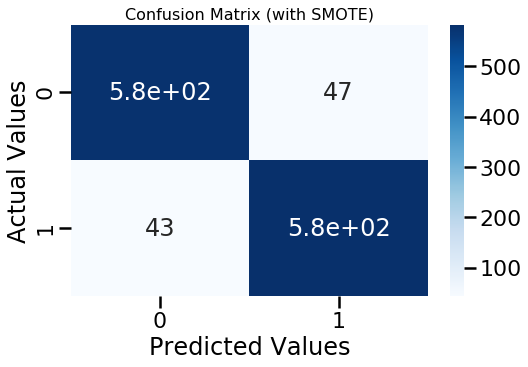

```python
# Heat Map (Showing the confusion matrics with SMOTE)
plt.figure(figsize=(8,5))
cm = cnf_matrix
cm_plot = sns.heatmap(cm, annot=True, cmap='Blues');
cm_plot.set_xlabel('Predicted Values')
cm_plot.set_ylabel('Actual Values')
cm_plot.set_title('Confusion Matrix (with SMOTE)', size=16)
```

```python
# Accuracy of the model
print("Accuracy:", metrics.accuracy_score(y_test, y_pred))
```

```
Accuracy: 0.928
```

```python
# precision of the model
from sklearn.metrics import precision_score
print("Precision:", precision_score(y_test, y_pred))
```

```
Precision: 0.9253968253968254
```

This shows 92.5% ratio of the true positives to all of the positive values(true and false positives)

```python
#Recall(Sensitivity) of the model
from sklearn.metrics import recall_score
print("Recall:", recall_score(y_test, y_pred))
```

```
Recall: 0.9313099041533547
```

This shows 93.1% ratio of the tue positives to the sum of the true positives and the false negatives

We may lastly plot the ROC (Receiver Operating Characteristic) Curve, which shows the percentage of true positives predicted by the model.

Our model can predict outcomes more precisely the greater the AUC (area under the curve):

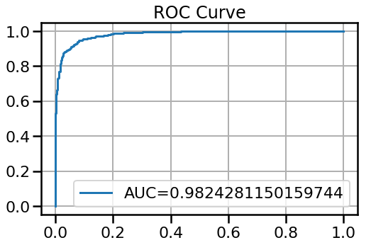

```python
#define metrics
y_pred_proba = log_regression.predict_proba(X_test)[::,1]
fpr, tpr, _ = metrics.roc_curve(y_test,  y_pred_proba)
auc = metrics.roc_auc_score(y_test, y_pred_proba)

#create ROC curve
plt.figure(figsize=(8,5))
plt.plot(fpr,tpr,label="AUC="+str(auc))
plt.legend(loc=4)
plt.title('ROC Curve')
plt.grid(True)
plt.show()
```

```python
print(classification_report(y_test, y_pred))
```

```
              precision    recall  f1-score   support

           0       0.93      0.92      0.93       624
           1       0.93      0.93      0.93       626

   micro avg       0.93      0.93      0.93      1250
   macro avg       0.93      0.93      0.93      1250
weighted avg       0.93      0.93      0.93      1250
```

## Conclusion

Starting with the initial step and adding libraries like NumPy, scikit-learn, StatsModels, Matplotlib, and other more libraries as we go with the analysis. To assure the calibre and objectivity of our research, we were able to input the dataset and check for missing values and infinities, which allowed us to clean up and obtain a new dataset. To examine several characteristics of the variables, we were able to plot some graphs, such as the distribution plot and the histogram plot, also calculate the skewness of the variables. In order for machine learning algorithms to use our category variables to provide more accurate predictions, we performed a OneHot Encoding to replace them with numerical variables.

Continuing with the Clustering using the K Means approach, choose my X and Y, take the diagnosis for the column in Y, drop Diagnosis solely, and keep other columns in X. This is from the Unsupervised learning analysis. Additionally, we divided the sets, used the MinMaxScaler to scale the data, and then used PCA to reduce the number of dimensions so that the findings could be displayed using a 2D scatter plot. checked the KMeans, the prediction, and the scatter plot visualisation.Elbow curve was used to determine the ideal cluster number (k), which we were able to obtain four (4). In order to evaluate the quality of clusters and confirm the optimal cluster, Silhouette scores were checked to demonstrate how successfully samples are clustered with comparable samples (k).

## Limitations

We can attempt to perform some skewness to obtain some features and test for normality and do some tranformation like the Log transform, Root transform or Box-Cox transform, classify cases of schizophrenia-like disease from controls using supervised learning, and perform dimensionality reduction and hierarchical clustering for further investigation.